# Acoustic correlates of perceived prominence in German and Catalan: Bayesian Modeling

##### 4.1.3.3.1 Effect comparison

```r
# Compute estimated marginal means on log-scale
em_mdl_f0_slopePostCat <- emmeans(mdl_f0_slopePostCat, ~ percProm)
print(em_mdl_f0_slopePostCat)
```

```
##  percProm   emmean lower.HPD upper.HPD
##  1         0.00453   -0.0188    0.0291
##  2         0.06272    0.0315    0.0942
##  3        -0.07870   -0.1201   -0.0358
##
## Results are averaged over the levels of: gender_s
## Point estimate displayed: median
## HPD interval probability: 0.95
```

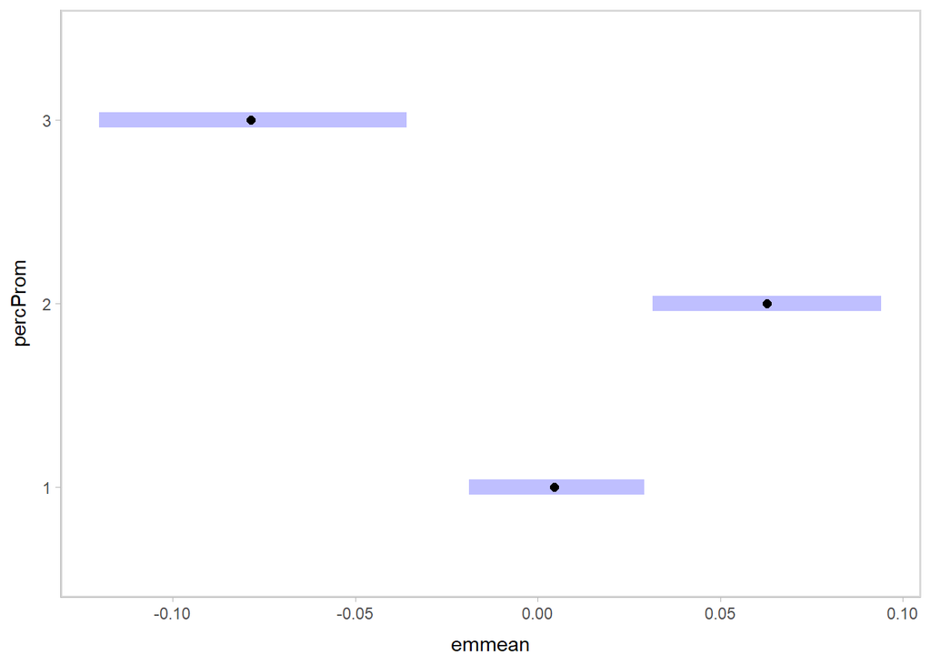

```r
plot(em_mdl_f0_slopePostCat)
```

```r
# Perform pairwise comparisons between levels of percProm
emPairs_mdl_f0_slopePostCat <- pairs(emmeans(mdl_f0_slopePostCat, ~ percProm))
print(emPairs_mdl_f0_slopePostCat)
```

```
##  contrast              estimate lower.HPD upper.HPD
##  percProm1 - percProm2  -0.0578   -0.0949   -0.0209
##  percProm1 - percProm3   0.0832    0.0383    0.1305
##  percProm2 - percProm3   0.1412    0.0952    0.1861
##
## Results are averaged over the levels of: gender_s
## Point estimate displayed: median
## HPD interval probability: 0.95
```

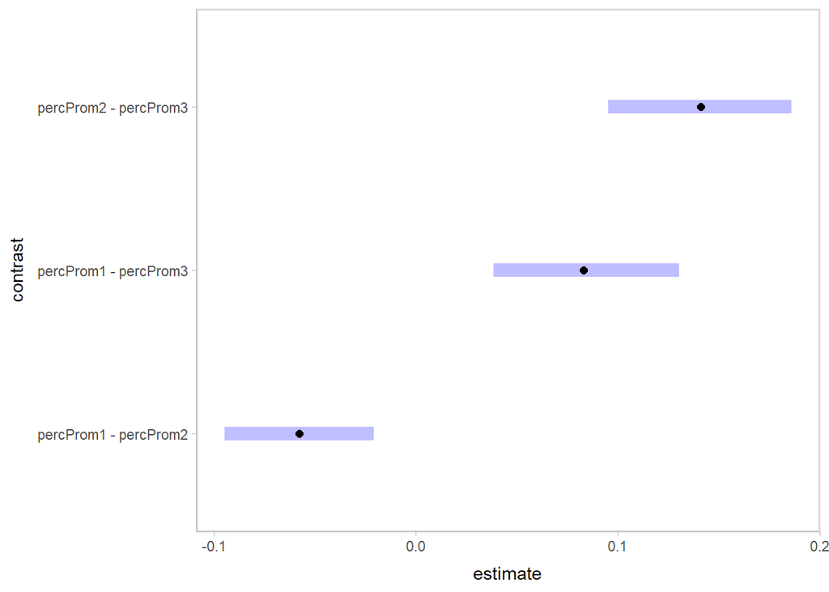

```r
plot(emPairs_mdl_f0_slopePostCat)
```

If the comparison includes 0, the contrast is not reliably different.

##### 4.1.3.3.2 Hypothesis testing

```r
# Extract posterior samples of the fixed effects coefficients
as_draws_df(mdl_f0_slopePostCat) %>%
  # Select fixed effects for percProm levels
  select(starts_with("b_percProm")) %>%
  # Rename columns to match percProm levels
  rename_with(~ str_replace(.x, "b_percProm", "percProm"), starts_with("b_percProm")) %>%
  # Compute differences between percProm levels
  mutate(
    diff_1_2 = percProm2 - percProm1,
    diff_1_3 = percProm3 - percProm1,
    diff_2_3 = percProm3 - percProm2
  ) %>%
  # Gather differences into long format
  pivot_longer(
    cols = starts_with("diff_"),
    names_to = "Comparison",
    values_to = "Difference"
  ) %>%
  # Group by comparison to compute summary statistics
  group_by(Comparison) %>%
  summarise(
    Estimate = mean(Difference),
    Est.Error = sd(Difference),
    CI.Lower = quantile(Difference, 0.025),
    CI.Upper = quantile(Difference, 0.975),
    Post.Prob = if_else(Estimate > 0,
                        mean(Difference > 0) * 100,
                        mean(Difference < 0) * 100)
  ) %>%
  ungroup() %>%
  # Add significance stars based on posterior probability
  mutate(
    Star = ifelse(Post.Prob > 95 | Post.Prob < 5, "*", ""),
    Estimate = round(Estimate, 3),
    Est.Error = round(Est.Error, 3),
    CI.Lower = round(CI.Lower, 3),
    CI.Upper = round(CI.Upper, 3),
    Post.Prob = round(Post.Prob, 2)
  ) %>%
  # Select and arrange the final columns
  select(Comparison, Estimate, Est.Error, CI.Lower, CI.Upper, Post.Prob, Star) %>%
  arrange(Comparison)
```

| Comparison | Estimate | Est.Error | CI.Lower | CI.Upper | Post.Prob | Star |
| --- | --- | --- | --- | --- | --- | --- |
| diff_1_2 | 0.058 | 0.019 | 0.021 | 0.096 | 99.93 | * |
| diff_1_3 | -0.083 | 0.024 | -0.128 | -0.036 | 99.88 | * |
| diff_2_3 | -0.141 | 0.023 | -0.186 | -0.095 | 100.00 | * |

**Overall Implications:**

- **Trend**: The findings suggest a non-linear trend in `f0_slopePostCat` across prominence levels, with a increase from `percProm1` to `percProm2` followed by a consistent decrease from `percProm1` (and `percProm2`) to `percProm3`.
- **Interpretation**: The posterior probabilities and credible intervals indicate strong support for these changes across the prominence levels, suggesting that `f0_slopePostCat` varies significantly in response to perceived prominence, with the largest decrease observed between `percProm2` and `percProm3`.

##### 4.1.3.3.3 Plot fixef

Visualize the (non-)linearity of the effect with a violin plot of the posteriors for each prominence level and a GAMM overlaid on top.

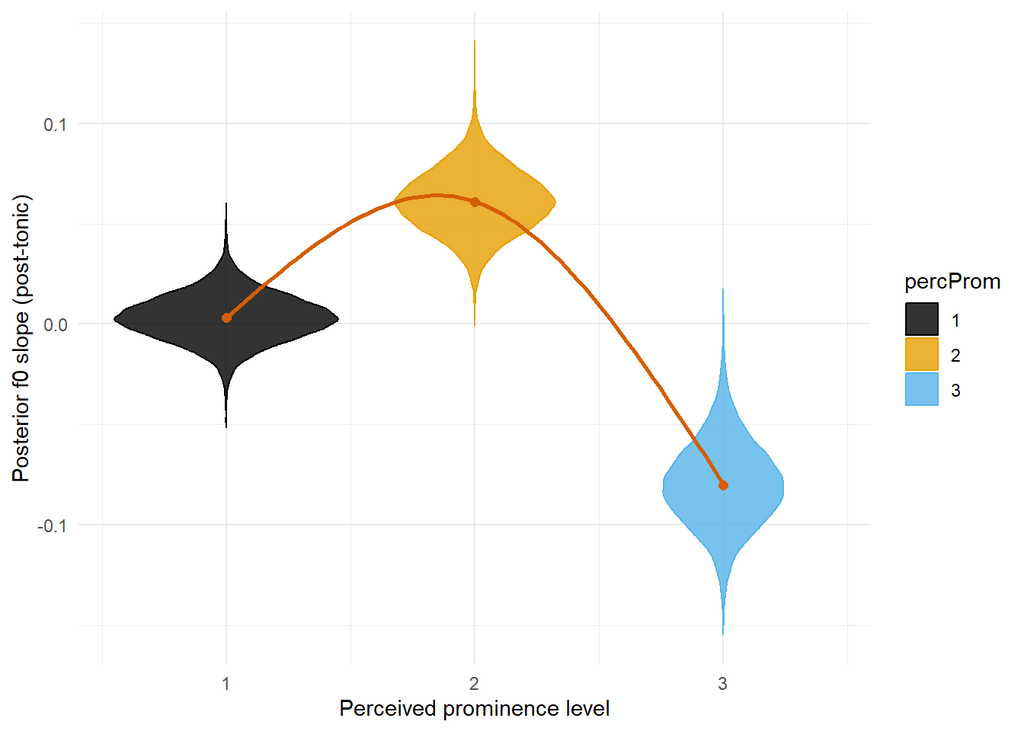

```r
data_prepost_cat %>%
  data_grid(percProm = unique(percProm),
            gender_s = 0.1563) %>% # Set to average of gender
  add_epred_draws(mdl_f0_slopePostCat, re_formula = NA) %>%
  mutate(
    percProm_num = as.numeric(as.character(percProm)),
    percProm = factor(percProm, levels = c("1", "2", "3"))
  ) %>%
  ggplot(aes(x = percProm_num, y = .epred, color = percProm)) +
  geom_violin(aes(group = percProm_num, fill = percProm), alpha = 0.8) +
  scale_color_manual(values = colorBlindBlack8) +
  scale_fill_manual(values = colorBlindBlack8) +
  stat_summary(fun = median, geom = "point", color = colorBlindBlack8[7], size = 2) +
  geom_smooth(
    aes(group = 1),
    method = "gam",
    formula = y ~ s(x, bs = "cs", k = 3),
    color = colorBlindBlack8[7],
    se = FALSE
  ) +
  scale_x_continuous(
    breaks = 0:3,
    labels = as.character(0:3)
  ) +
  #ylim(1, 5) +
  labs(
    x = "Perceived prominence level",
    y = "Posterior f0 slope (post-tonic)"
  ) +
  theme_minimal()
```

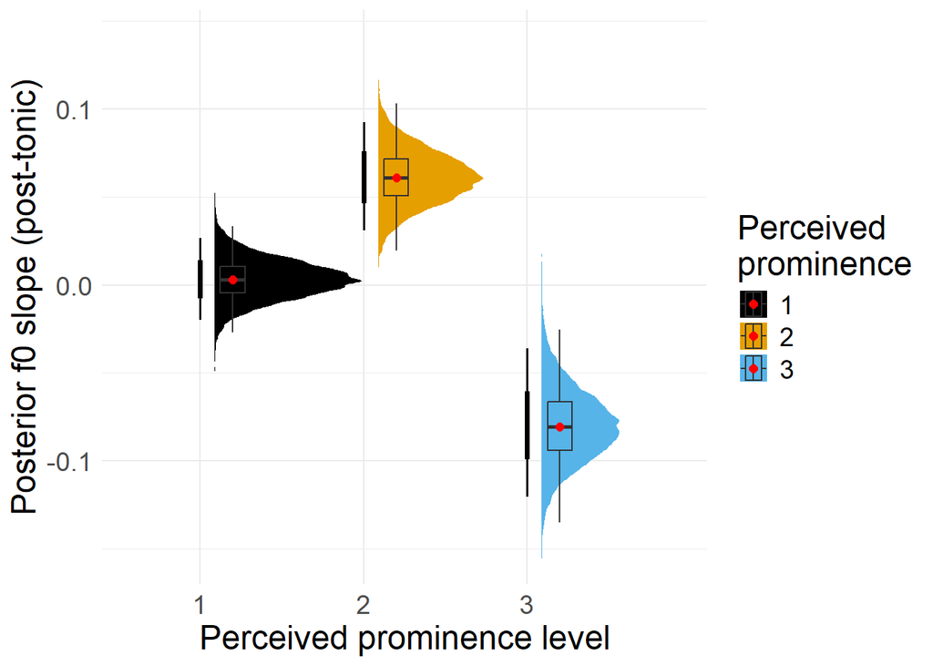

```r
post_f0_slopePostCat <-
  data_prepost_cat %>%
  data_grid(
    percProm = unique(percProm),
    gender_s = 0.1563  # Set gender_s to zero to average over gender
  ) %>%
  add_epred_draws(mdl_f0_slopePostCat, re_formula = NA) %>%
  mutate(
    percProm = factor(percProm, levels = c("1", "2", "3"))
  ) %>%
  ggplot(aes(y = percProm, x = .epred, fill = percProm)) +
  ggdist::stat_halfeye(
    adjust = 0.5,
    width = 0.6,
    .width = c(0.66, 0.95),
    justification = -0.1,
    point_colour = NA
  ) +
  geom_boxplot(
    width = 0.15,
    outlier.shape = NA,
    alpha = 0.5,
    position = position_nudge(y = 0.2)
  ) +
  stat_summary(
    fun = median,
    geom = "point",
    color = "red",
    size = 2,
    position = position_nudge(y = 0.2)
  ) +
  scale_fill_manual(values = colorBlindBlack8) +
  coord_flip() +
  theme_minimal() +
  theme(text = element_text(size = 18)) +
  #xlim(1, 3.5) +
  labs(
    y = "Perceived prominence level",
    x = "Posterior f0 slope (post-tonic)",
    fill = "Perceived\nprominence"
  )

post_f0_slopePostCat;
```

```r
ggsave(plot = post_f0_slopePostCat, filename = paste0(plots, "posterior_f0_slopePostCat.pdf"),
       width = 8, height = 6);
ggsave(plot = post_f0_slopePostCat, filename = paste0(plots, "posterior_f0_slopePostCat.jpg"),
       width = 8, height = 6);
ggsave(plot = post_f0_slopePostCat, filename = paste0(plots, "posterior_f0_slopePostCat.tif"),
       width = 8, height = 6, compression="lzw", dpi=600);
```

#### 4.1.3.4 Group-level effects

First, get a general overview.

```r
as.data.frame(VarCorr(mdl_f0_slopePostCat)$participant$sd) %>%
  rownames_to_column(var = "Random Effect") %>%
  select(`Random Effect`, Estimate, Est.Error, Q2.5, Q97.5)
```

| Random Effect | Estimate | Est.Error | Q2.5 | Q97.5 |
| --- | --- | --- | --- | --- |
| percProm1 | 0.02676223 | 0.01706826 | 0.001241386 | 0.06343998 |
| percProm2 | 0.08428769 | 0.01304998 | 0.062111160 | 0.11319804 |
| percProm3 | 0.08767092 | 0.02363509 | 0.045638208 | 0.13796749 |

- **percProm1**: The estimated standard deviation of random effects at `percProm1` is 0.027 (95% CrI: 0.001 to 0.063), suggesting limited variability among participants’ responses at this level. Although small, the credible interval indicates some uncertainty, allowing for variability in individual responses.
- **percProm2**: The estimated standard deviation at `percProm2` is 0.084 (95% CrI: 0.062 to 0.113), indicating moderate variability among participants. The narrower credible interval compared to `percProm1` suggests that the variation in response is more consistently observed at this level.
- **percProm3**: The estimated standard deviation at `percProm3` is 0.088 (95% CrI: 0.046 to 0.138), indicating moderate variability. The credible interval highlights that participants show more individualized responses at this level, which could be due to different interpretations of prominence.

**Overall Implications:**

- **Trend**: Participant variability in `f0_slopePostCat` tends to increase as the prominence level rises from `percProm1` to `percProm3`.
- **Interpretation**: These results suggest that responses at higher prominence levels (`percProm2` and `percProm3`) exhibit greater participant-specific variability, possibly reflecting more nuanced individual differences in response to perceived prominence at these levels.

Extract samples in interpretable units. Then, plot them so that we can see how each participant uses the levels of percProm.

```r
# Extract samples for each participant x percProm
data_prepost_cat %>%
  data_grid(
    participant = unique(participant),
    percProm = unique(percProm),
    gender_s = 0.1563 # Average over gender
  ) %>%
  add_epred_draws(mdl_f0_slopePostCat) %>%
  median_qi()
```

| participant | percProm | gender_s | .row | .epred | .lower | .upper | .width | .point | .interval |
| --- | --- | --- | --- | --- | --- | --- | --- | --- | --- |
| 1 | 1 | 0.1563 | 1 | 0.0024920259 | -0.059838700 | 0.058052755 | 0.95 | median | qi |
| 1 | 2 | 0.1563 | 2 | 0.0715777725 | -0.002725680 | 0.148352046 | 0.95 | median | qi |
| 1 | 3 | 0.1563 | 3 | -0.0343625269 | -0.163024247 | 0.128603270 | 0.95 | median | qi |
| 2 | 1 | 0.1563 | 4 | 0.0105019412 | -0.033700755 | 0.085797260 | 0.95 | median | qi |
| 2 | 2 | 0.1563 | 5 | 0.0711215287 | -0.009521426 | 0.163822684 | 0.95 | median | qi |
| 2 | 3 | 0.1563 | 6 | -0.0317970830 | -0.122286114 | 0.057066831 | 0.95 | median | qi |
| 3 | 1 | 0.1563 | 7 | -0.0011193303 | -0.073563483 | 0.054511008 | 0.95 | median | qi |
| 3 | 2 | 0.1563 | 8 | 0.0514452505 | -0.033920546 | 0.138646581 | 0.95 | median | qi |
| 3 | 3 | 0.1563 | 9 | -0.1198729283 | -0.206398350 | -0.037758098 | 0.95 | median | qi |
| 4 | 1 | 0.1563 | 10 | 0.0017510141 | -0.050078142 | 0.049731579 | 0.95 | median | qi |

[output cut: 95 more lines]

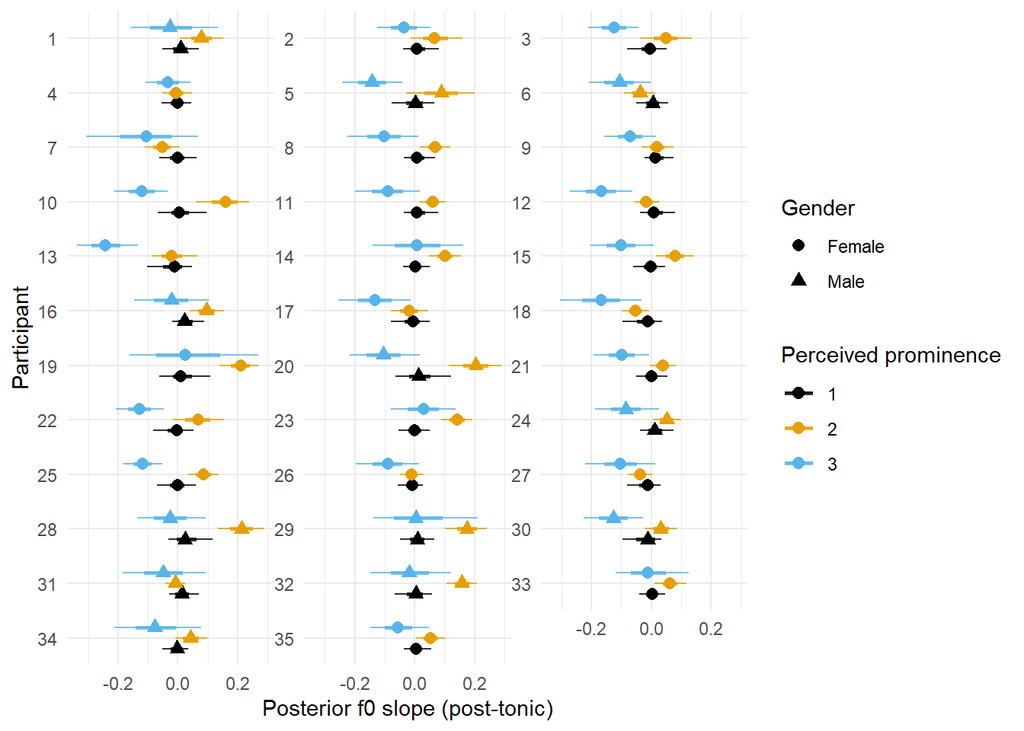

```r
# Plot the draws for all participants x percProm levels
data_prepost_cat %>%
  # Start by selecting unique participants and their gender_s
  select(participant, gender_s) %>%
  distinct() %>%
  # Back-transform gender_s to gender labels
  mutate(
    gender = if_else(gender_s == -0.5, "Male", "Female")
  ) %>%
  # Combine with percProm levels
  crossing(
    percProm = unique(data_prepost_cat$percProm)
  ) %>%
  # Generate posterior predictions
  add_epred_draws(mdl_f0_slopePostCat) %>%
  # Summarize predictions with .66 and .95 intervals
  median_qi(.width = c(.66, .95)) %>%
  ggplot(aes(x = .epred, y = participant, color = percProm, shape = gender)) +
  # Add the thick line for 66% credible interval
  geom_linerange(aes(xmin = .lower, xmax = .upper, group = .width),
                 data = ~ filter(., .width == 0.66),  # Use 66% credible interval
                 size = 1,
                 alpha = 0.8,
                 position = position_dodge2(width = 0.7, padding = 0.5)) +
  # Add the thin line for 95% credible interval
  geom_linerange(aes(xmin = .lower, xmax = .upper, group = .width),
                 data = ~ filter(., .width == 0.95),  # Use 95% credible interval
                 size = 0.5,
                 alpha = 0.8,
                 position = position_dodge2(width = 0.7, padding = 0.5)) +
  # Add points with shapes
  geom_point(position = position_dodge(width = 0.7), size = 2.5) +
  scale_color_manual(values = colorBlindBlack8) +
  labs(
    x = "Posterior f0 slope (post-tonic)",
    y = "Participant",
    color = "Perceived prominence",
    shape = "Gender"
  ) +
  theme_minimal() +
  facet_wrap(~ participant, ncol = 3, scales = "free_y") +
  theme(
    strip.text = element_blank(),
    panel.spacing = unit(0, "lines")
  )
```

First, we extract individual draws. Here, if the CrI encompasses 0, the participant does not differ from the overall behavior on this percProm. Then, we plot random effects for each participant and percProm level on the model scale, representing deviations from the fixed effects.

```r
# We focus on 95% CrI, but this can be adapted in the width parameter
mdl_f0_slopePostCat %>%
  spread_draws(r_participant[participant,percProm]) %>%
  median_qi(r_participant, .width = c(.95))
```

| participant | percProm | r_participant | .lower | .upper | .width | .point | .interval |
| --- | --- | --- | --- | --- | --- | --- | --- |
| 1 | percProm1 | -0.0001587156 | -0.0621803848 | 0.053813620 | 0.95 | median | qi |
| 1 | percProm2 | 0.0104548652 | -0.0682360831 | 0.091106360 | 0.95 | median | qi |
| 1 | percProm3 | 0.0462175149 | -0.0819281944 | 0.202362899 | 0.95 | median | qi |
| 2 | percProm1 | 0.0055039434 | -0.0350798242 | 0.082213185 | 0.95 | median | qi |
| 2 | percProm2 | 0.0099448096 | -0.0738412680 | 0.105228174 | 0.95 | median | qi |
| 2 | percProm3 | 0.0477792383 | -0.0451062863 | 0.140413507 | 0.95 | median | qi |
| 3 | percProm1 | -0.0027330392 | -0.0718237996 | 0.045893579 | 0.95 | median | qi |
| 3 | percProm2 | -0.0092676912 | -0.0970586985 | 0.078706006 | 0.95 | median | qi |
| 3 | percProm3 | -0.0397459097 | -0.1334140707 | 0.046199518 | 0.95 | median | qi |
| 4 | percProm1 | -0.0005978390 | -0.0565104325 | 0.049449231 | 0.95 | median | qi |

[output cut: 95 more lines]

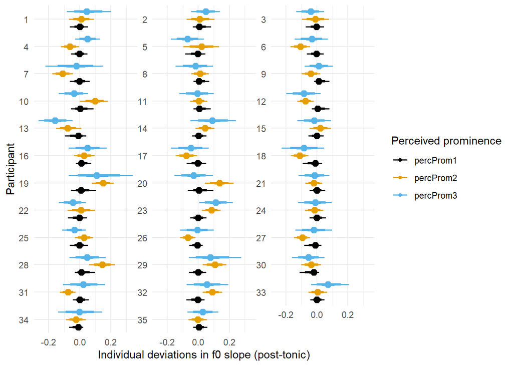

```r
# In log without Intercept
mdl_f0_slopePostCat %>%
  spread_draws(r_participant[participant,percProm]) %>%
  median_qi(r_participant, .width = c(.95, .8, .5)) %>%
  ggplot(aes(y = as.factor(participant), x = r_participant, color = percProm, xmin = .lower, xmax = .upper)) +
  geom_pointinterval(
    position = "dodge") +
  scale_color_manual(
    values = colorBlindBlack8) +
  labs(
    x = "Individual deviations in f0 slope (post-tonic)",
    y = "Participant",
    color = "Perceived prominence") +
  theme_minimal() +
  facet_wrap(~ participant, ncol = 3, scales = "free_y") +
  theme(
    strip.text = element_blank(),
    panel.spacing = unit(0, "lines")
  )
```

### 4.1.4 Frequency modulation median (post-tonic)

#### 4.1.4.1 Priors

| prior | class | coef | group | resp | dpar | nlpar | lb | ub | source |
| --- | --- | --- | --- | --- | --- | --- | --- | --- | --- |
|  | b |  |  |  |  |  |  |  | default |
|  | b | gender_s |  |  |  |  |  |  | default |
|  | b | percProm1 |  |  |  |  |  |  | default |
|  | b | percProm2 |  |  |  |  |  |  | default |
|  | b | percProm3 |  |  |  |  |  |  | default |
| lkj(1) | cor |  |  |  |  |  |  |  | default |
|  | cor |  | participant |  |  |  |  |  | default |
| student_t(3, 0, 2.5) | sd |  |  |  |  |  | 0 |  | default |
|  | sd |  | participant |  |  |  |  |  | default |
|  | sd | percProm1 | participant |  |  |  |  |  | default |

[output cut: 3 more lines]

#### 4.1.4.2 Model

Calculate R².

```
##     Estimate  Est.Error      Q2.5     Q97.5
## R2 0.1697246 0.03077909 0.1188154 0.2373562
```

An R² of approximately 0.17 suggests a **modest fit**, indicating that the model explains about **17%** of the variance in the dependent variable `fmDep_medianPostCat`. This means that just under one-fifth of the variability in `fmDep_medianPostCat` is accounted for by the predictors. The 95% credible interval, which ranges from **11.9% to 23.7%**, reflects some uncertainty around the exact R² value but still suggests a modest level of explanatory power for the model.

#### 4.1.4.3 Fixed effects

Let’s check how it looks like.

```
##  Family: lognormal
##   Links: mu = identity; sigma = identity
## Formula: fmDep_medianPost ~ 0 + percProm + gender_s + (0 + percProm | participant)
##    Data: data_prepost_cat (Number of observations: 1568)
##   Draws: 4 chains, each with iter = 8000; warmup = 4000; thin = 1;
##          total post-warmup draws = 16000
##
## Multilevel Hyperparameters:
## ~participant (Number of levels: 35)
##                          Estimate Est.Error l-95% CI u-95% CI Rhat Bulk_ESS
## sd(percProm1)                1.73      0.22     1.36     2.22 1.00     4168
## sd(percProm2)                1.45      0.16     1.18     1.80 1.00     3678
## sd(percProm3)                1.46      0.21     1.12     1.93 1.00     5291
## cor(percProm1,percProm2)     0.91      0.04     0.81     0.97 1.00     4828
## cor(percProm1,percProm3)     0.96      0.03     0.87     1.00 1.00     5600
## cor(percProm2,percProm3)     0.96      0.03     0.89     0.99 1.00     9874
##                          Tail_ESS
## sd(percProm1)                7223
## sd(percProm2)                6821
## sd(percProm3)                8810
## cor(percProm1,percProm2)     7980
## cor(percProm1,percProm3)     7270
## cor(percProm2,percProm3)    12723
##
## Regression Coefficients:
##           Estimate Est.Error l-95% CI u-95% CI Rhat Bulk_ESS Tail_ESS
## percProm1     0.17      0.16     0.00     0.58 1.00    11132     9714
## percProm2     0.06      0.06     0.00     0.22 1.00    17647     9086
## percProm3     0.19      0.16     0.01     0.61 1.00    15008     9894
## gender_s      0.13      0.12     0.00     0.45 1.00    12949     9816
##
## Further Distributional Parameters:
##       Estimate Est.Error l-95% CI u-95% CI Rhat Bulk_ESS Tail_ESS
## sigma     1.15      0.02     1.10     1.19 1.00    27409    11229
##
## Draws were sampled using sampling(NUTS). For each parameter, Bulk_ESS
## and Tail_ESS are effective sample size measures, and Rhat is the potential
## scale reduction factor on split chains (at convergence, Rhat = 1).
```

```
##           Estimate Est.Error     Q2.5    Q97.5
## percProm1 1.185990  1.171717 1.004751 1.783663
## percProm2 1.060646  1.059923 1.001607 1.242110
## percProm3 1.204865  1.179075 1.005220 1.832147
## gender_s  1.135661  1.129941 1.003480 1.565454
```

It shows a decrease from 1 to 2 and then increase from 2 to 3. 1 and 3 are the same.

Diagnostic plots.

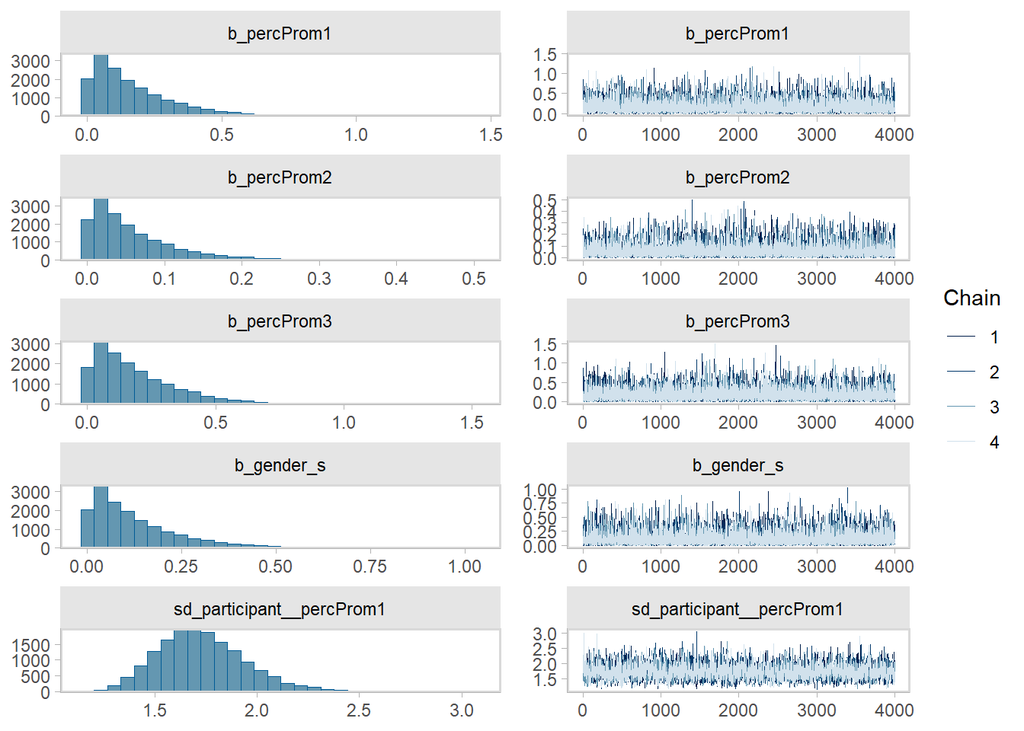

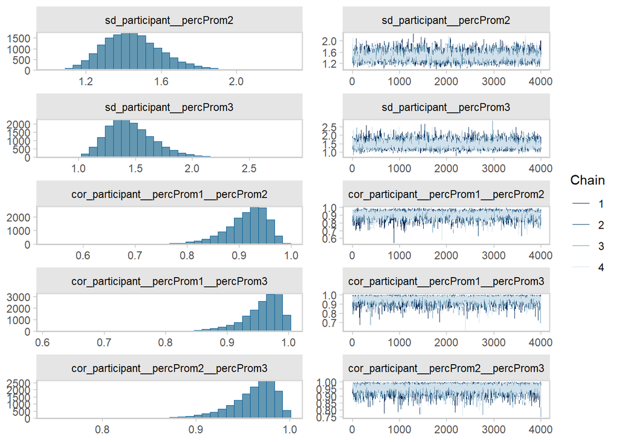

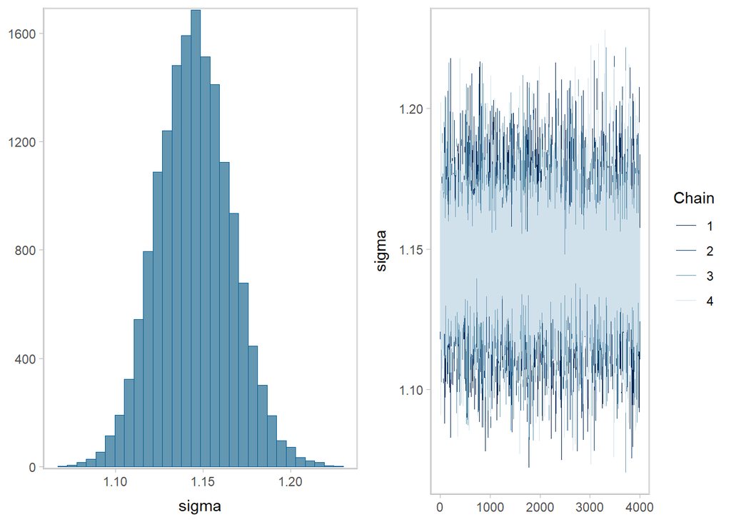

Posterior predictive check.

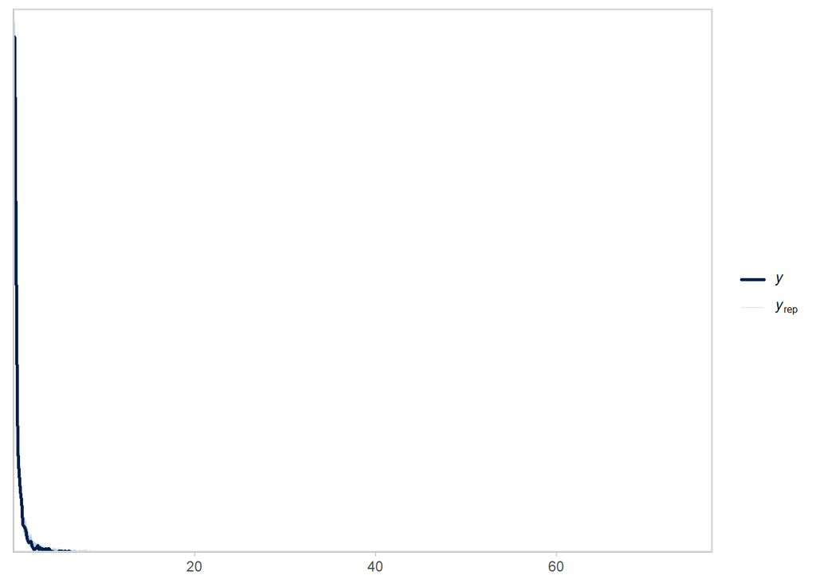

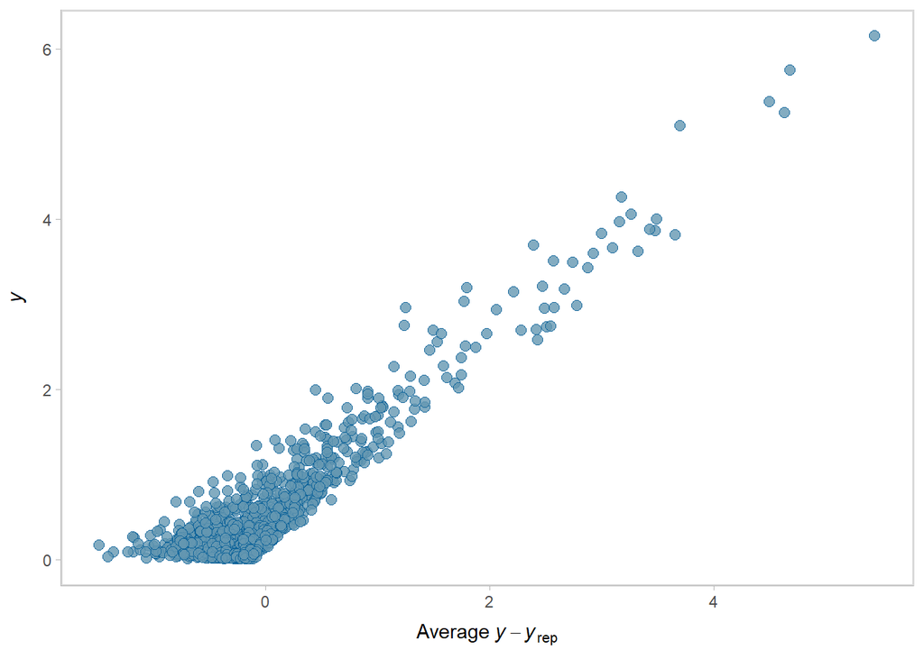

Extract samples.

| variable | mean | median | sd | mad | q5 | q95 | rhat | ess_bulk | ess_tail |
| --- | --- | --- | --- | --- | --- | --- | --- | --- | --- |
| b_percProm1 | 0.17057752 | 0.12376475 | 0.15847030 | 0.12557764 | 0.009287996 | 0.4866129 | 1.0004115 | 11132.09 | 9714.265 |
| b_percProm2 | 0.05887815 | 0.04114864 | 0.05819642 | 0.04271548 | 0.003044479 | 0.1772539 | 1.0000645 | 17646.99 | 9085.905 |
| b_percProm3 | 0.18636756 | 0.14295432 | 0.16472988 | 0.13947062 | 0.010515001 | 0.5085862 | 0.9999883 | 15008.05 | 9894.349 |
| b_gender_s | 0.12721470 | 0.09053458 | 0.12216546 | 0.09317640 | 0.007047946 | 0.3732943 | 1.0002459 | 12949.12 | 9815.957 |
| exp_b_percProm1 | 1.20238127 | 1.13174959 | 0.22046631 | 0.13941311 | 1.009331263 | 1.6267968 | 1.0004115 | 11132.09 | 9714.265 |
| exp_b_percProm2 | 1.06251018 | 1.04200698 | 0.06540797 | 0.04417787 | 1.003049118 | 1.1939342 | 1.0000632 | 17646.99 | 9085.905 |
| exp_b_percProm3 | 1.22283352 | 1.15367710 | 0.23295772 | 0.15752023 | 1.010570478 | 1.6629385 | 0.9999945 | 15008.05 | 9894.349 |

Check conditional effect.

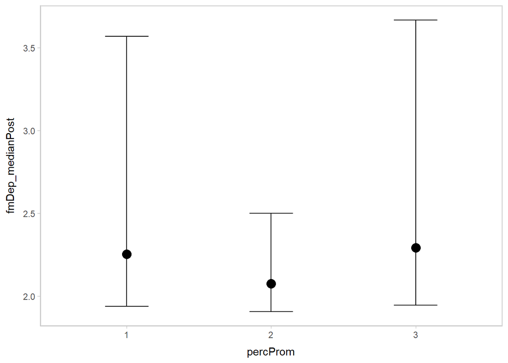

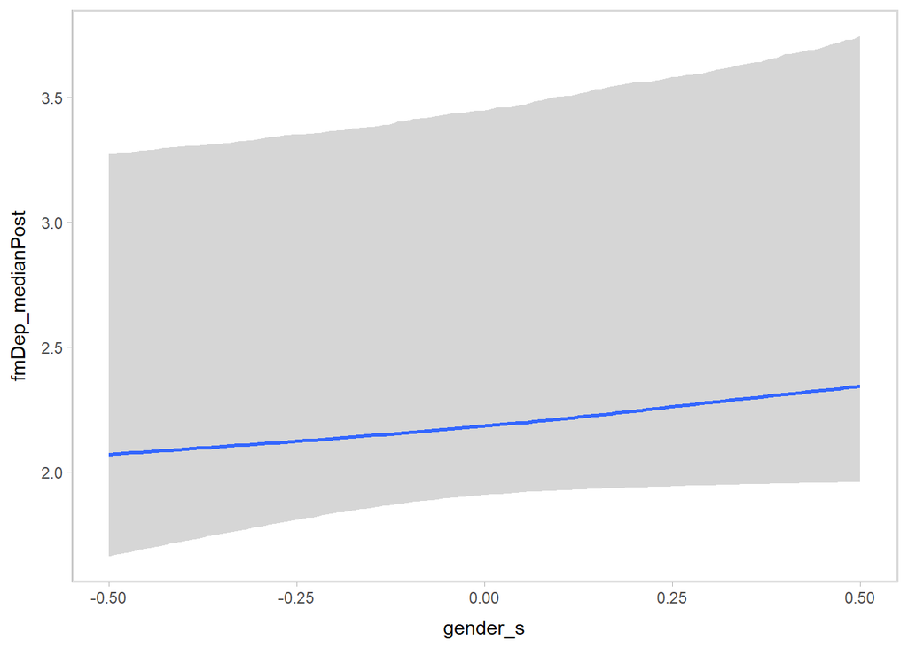

| percProm | fmDep_medianPost | gender_s | participant | cond__ | effect1__ | estimate__ | se__ | lower__ | upper__ |
| --- | --- | --- | --- | --- | --- | --- | --- | --- | --- |
| 1 | 0.4452678 | 0.2244898 | NA | 1 | 1 | 2.252776 | 0.2887355 | 1.939054 | 3.568406 |
| 2 | 0.4452678 | 0.2244898 | NA | 1 | 2 | 2.074463 | 0.1219631 | 1.906892 | 2.499014 |
| 3 | 0.4452678 | 0.2244898 | NA | 1 | 3 | 2.292859 | 0.3227768 | 1.945493 | 3.667887 |

Compare conditional effects to raw values.

| percProm | avg_fmDep_medianPost |
| --- | --- |
| 1 | 0.4421848 |
| 2 | 0.4327798 |
| 3 | 0.5207636 |

```
##    Min. 1st Qu.  Median    Mean 3rd Qu.    Max.    NA's
##  0.0007  0.1037  0.2250  0.4453  0.4770  6.1503     678
```

##### 4.1.4.3.1 Effect comparison

```
##  percProm emmean lower.HPD upper.HPD
##  1          1.14         1      1.63
##  2          1.05         1      1.20
##  3          1.16         1      1.67
##
## Results are averaged over the levels of: gender_s
## Point estimate displayed: median
## HPD interval probability: 0.95
```

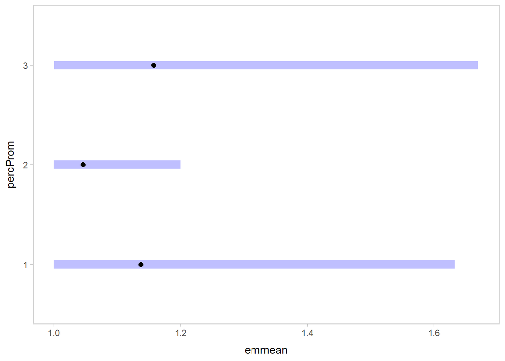

```
##  contrast              estimate lower.HPD upper.HPD
##  percProm1 - percProm2   0.0794    -0.198     0.631
##  percProm1 - percProm3  -0.0130    -0.683     0.615
##  percProm2 - percProm3  -0.0995    -0.665     0.195
##
## Results are averaged over the levels of: gender_s
## Point estimate displayed: median
## HPD interval probability: 0.95
```

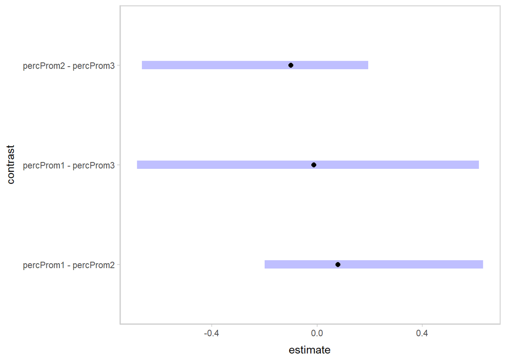

If the comparison includes 0, the contrast is not reliably different.

##### 4.1.4.3.2 Hypothesis testing

| Comparison | Estimate | Est.Error | CI.Lower | CI.Upper | Post.Prob | Star |
| --- | --- | --- | --- | --- | --- | --- |
| diff_1_2 | -0.14 | 0.228 | -0.733 | 0.140 | 75.44 |  |
| diff_1_3 | 0.02 | 0.313 | -0.628 | 0.666 | 52.90 |  |
| diff_2_3 | 0.16 | 0.239 | -0.138 | 0.769 | 78.19 |  |

- **`diff_1_2`:** Estimate = -0.14 [-0.733, 0.14], Posterior Probability = 75.4%; There is moderate evidence suggesting that `fmDep_medianPostCat` at `percProm2` may be lower than at `percProm1`. However, the credible interval includes zero, indicating that this difference is not reliable.
- **`diff_1_3`:** Estimate = 0.02 [-0.628, 0.666], Posterior Probability = 52.9%; There is no strong evidence for a difference between `percProm1` and `percProm3`. The posterior probability is near chance, and the wide credible interval includes zero, making the difference inconclusive.
- **`diff_2_3`:** Estimate = 0.16 [-0.138, 0.769], Posterior Probability = 78.2%; There is moderate evidence that `fmDep_medianPostCat` at `percProm3` might be higher than at `percProm2`, but the credible interval includes zero, suggesting that this difference is not robust.

**Overall Implications:**

- **Trend:** There is no clear, strong evidence of reliable differences in `fmDep_medianPostCat` between the `percProm` levels. While there is moderate evidence for some comparisons, the inclusion of zero in all credible intervals indicates that the results are inconclusive.

##### 4.1.4.3.3 Plot fixef

Visualize the (non-)linearity of the effect with a violin plot of the posteriors for each prominence level and a GAMM overlaid on top.

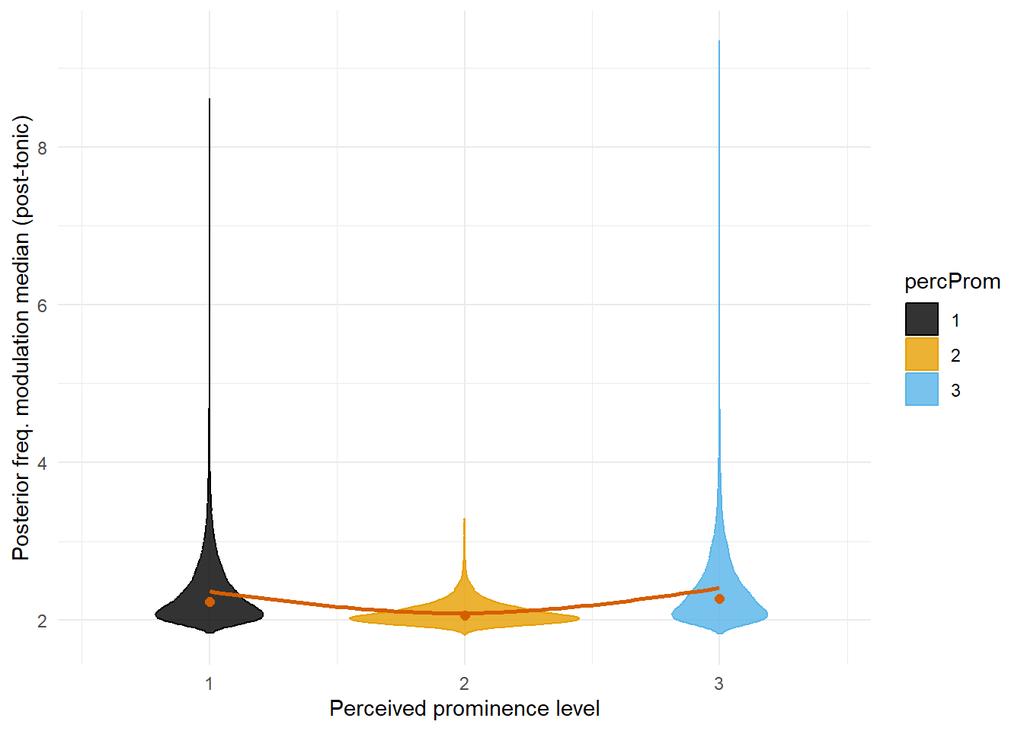

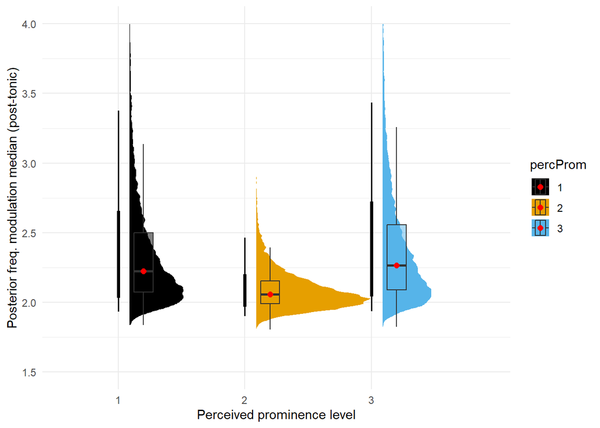

#### 4.1.4.4 Group-level effects

First, get a general overview.

| Random Effect | Estimate | Est.Error | Q2.5 | Q97.5 |
| --- | --- | --- | --- | --- |
| percProm1 | 1.731781 | 0.2190019 | 1.358668 | 2.221351 |
| percProm2 | 1.450773 | 0.1576433 | 1.178574 | 1.797718 |
| percProm3 | 1.457476 | 0.2091516 | 1.116067 | 1.928866 |

- **percProm1:** The estimated standard deviation is 1.732 (95% CrI: 1.359 to 2.221), suggesting substantial variability in participants’ responses at `percProm1`.
- **percProm2:** The estimated standard deviation is 1.451 (95% CrI: 1.179 to 1.798), indicating moderate variability at `percProm2`, which is slightly lower than at `percProm1`.
- **percProm3:** The estimated standard deviation is 1.457 (95% CrI: 1.116 to 1.929), showing similar variability to `percProm2`, though with a slightly wider credible interval, suggesting some uncertainty in participants’ responses at this level.

These results highlight that there is considerable participant-level variability in `fmDep_medianPostCat` across perceived prominence levels, with `percProm1` showing the greatest variability.

Extract samples in interpretable units. Then, plot them so that we can see how each participant uses the levels of percProm.

| participant | percProm | gender_s | .row | .epred | .lower | .upper | .width | .point | .interval |
| --- | --- | --- | --- | --- | --- | --- | --- | --- | --- |
| 1 | 1 | 0.1563 | 1 | 0.4703436 | 0.18480020 | 1.2381804 | 0.95 | median | qi |
| 1 | 2 | 0.1563 | 2 | 0.5179797 | 0.34747851 | 0.7949581 | 0.95 | median | qi |
| 1 | 3 | 0.1563 | 3 | 0.5946167 | 0.34854943 | 1.0357831 | 0.95 | median | qi |
| 2 | 1 | 0.1563 | 4 | 0.1205499 | 0.04181073 | 0.3056487 | 0.95 | median | qi |
| 2 | 2 | 0.1563 | 5 | 0.4617932 | 0.31004451 | 0.6990308 | 0.95 | median | qi |
| 2 | 3 | 0.1563 | 6 | 0.2958511 | 0.16476524 | 0.5157551 | 0.95 | median | qi |
| 3 | 1 | 0.1563 | 7 | 0.4000362 | 0.17222034 | 0.9493772 | 0.95 | median | qi |
| 3 | 2 | 0.1563 | 8 | 0.5158341 | 0.34534858 | 0.7628847 | 0.95 | median | qi |
| 3 | 3 | 0.1563 | 9 | 0.5002184 | 0.31521468 | 0.7849025 | 0.95 | median | qi |
| 4 | 1 | 0.1563 | 10 | 0.1774050 | 0.10081015 | 0.3117181 | 0.95 | median | qi |

[output cut: 95 more lines]

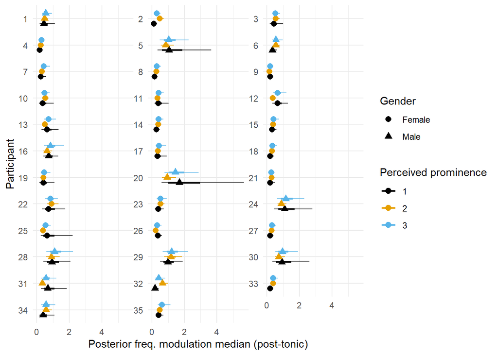

First, we extract individual draws. Here, if the CrI encompasses 0, the participant does not differ from the overall behavior on this percProm. Then, we plot random effects for each participant and percProm level on the model scale, representing deviations from the fixed effects.

| participant | percProm | r_participant | .lower | .upper | .width | .point | .interval |
| --- | --- | --- | --- | --- | --- | --- | --- |
| 1 | percProm1 | -1.5956664 | -2.5809850 | -0.617608541 | 0.95 | median | qi |
| 1 | percProm2 | -1.3885511 | -1.8023994 | -0.980145450 | 0.95 | median | qi |
| 1 | percProm3 | -1.3695020 | -2.0084940 | -0.797184180 | 0.95 | median | qi |
| 2 | percProm1 | -2.9512949 | -4.1072745 | -1.981729863 | 0.95 | median | qi |
| 2 | percProm2 | -1.5068232 | -1.9350599 | -1.077239845 | 0.95 | median | qi |
| 2 | percProm3 | -2.0663209 | -2.8126929 | -1.461991763 | 0.95 | median | qi |
| 3 | percProm1 | -1.7570035 | -2.6734595 | -0.872575815 | 0.95 | median | qi |
| 3 | percProm2 | -1.3938010 | -1.8217485 | -0.984256415 | 0.95 | median | qi |
| 3 | percProm3 | -1.5409758 | -2.1632182 | -1.040996199 | 0.95 | median | qi |
| 4 | percProm1 | -2.5679202 | -3.2650482 | -1.951008014 | 0.95 | median | qi |

[output cut: 95 more lines]

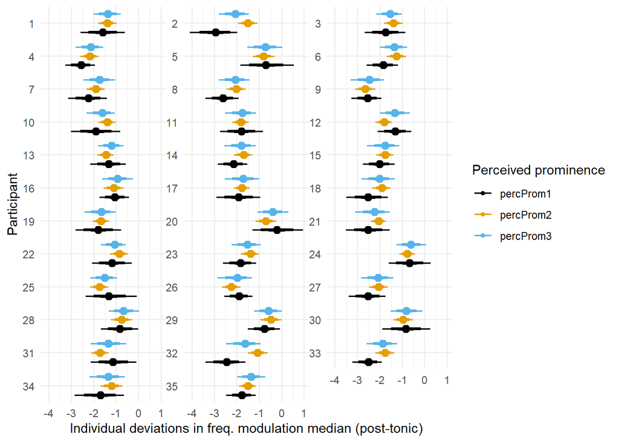

### 4.1.5 Shannon entropy SD

#### 4.1.5.1 Priors

| prior | class | coef | group | resp | dpar | nlpar | lb | ub | source |
| --- | --- | --- | --- | --- | --- | --- | --- | --- | --- |
|  | b |  |  |  |  |  |  |  | default |
|  | b | gender_s |  |  |  |  |  |  | default |
|  | b | percProm1 |  |  |  |  |  |  | default |
|  | b | percProm2 |  |  |  |  |  |  | default |
|  | b | percProm3 |  |  |  |  |  |  | default |
| lkj(1) | cor |  |  |  |  |  |  |  | default |
|  | cor |  | participant |  |  |  |  |  | default |
| student_t(3, 0, 2.5) | sd |  |  |  |  |  | 0 |  | default |
|  | sd |  | participant |  |  |  |  |  | default |
|  | sd | percProm1 | participant |  |  |  |  |  | default |

[output cut: 3 more lines]

#### 4.1.5.2 Model

Calculate R².

```
##     Estimate  Est.Error      Q2.5     Q97.5
## R2 0.2572849 0.01543586 0.2273162 0.2876225
```

An R² of approximately 0.26 suggests a **modest fit**. This value indicates that the model explains about **25.7%** of the variance in the dependent variable `entropySh_sd`. In other words, slightly more than a quarter of the variability in `entropySh_sd` is accounted for by the predictors in the model. The 95% credible interval, ranging from **22.7% to 28.8%**, shows some uncertainty around this estimate, but it provides a stable indication of the model’s explanatory power.

#### 4.1.5.3 Fixed effects

Let’s check how it looks like.

```
##  Family: lognormal
##   Links: mu = identity; sigma = identity
## Formula: entropySh_sd ~ 0 + percProm + gender_s + (0 + percProm | participant)
##    Data: data_prepost_cat (Number of observations: 2245)
##   Draws: 4 chains, each with iter = 8000; warmup = 4000; thin = 1;
##          total post-warmup draws = 16000
##
## Multilevel Hyperparameters:
## ~participant (Number of levels: 35)
##                          Estimate Est.Error l-95% CI u-95% CI Rhat Bulk_ESS
## sd(percProm1)                2.74      0.23     2.31     3.23 1.00      987
## sd(percProm2)                2.61      0.21     2.22     3.05 1.01      922
## sd(percProm3)                2.69      0.24     2.25     3.20 1.00     1180
## cor(percProm1,percProm2)     1.00      0.00     0.99     1.00 1.00     4233
## cor(percProm1,percProm3)     1.00      0.00     0.99     1.00 1.00     4642
## cor(percProm2,percProm3)     1.00      0.00     1.00     1.00 1.00     5539
##                          Tail_ESS
## sd(percProm1)                1896
## sd(percProm2)                1874
## sd(percProm3)                2310
## cor(percProm1,percProm2)     8042
## cor(percProm1,percProm3)     8224
## cor(percProm2,percProm3)    10058
##
## Regression Coefficients:
##           Estimate Est.Error l-95% CI u-95% CI Rhat Bulk_ESS Tail_ESS
## percProm1     0.16      0.14     0.00     0.54 1.00    15015     8945
## percProm2     0.11      0.11     0.00     0.40 1.00    16910     8873
## percProm3     0.20      0.18     0.01     0.66 1.00    12134     7816
## gender_s      0.28      0.24     0.01     0.91 1.00     3024     3170
##
## Further Distributional Parameters:
##       Estimate Est.Error l-95% CI u-95% CI Rhat Bulk_ESS Tail_ESS
## sigma     0.48      0.01     0.47     0.50 1.00    23597    11899
##
## Draws were sampled using sampling(NUTS). For each parameter, Bulk_ESS
## and Tail_ESS are effective sample size measures, and Rhat is the potential
## scale reduction factor on split chains (at convergence, Rhat = 1).
```

```
##           Estimate Est.Error     Q2.5    Q97.5
## percProm1 1.169202  1.155980 1.004436 1.714580
## percProm2 1.120618  1.113236 1.002985 1.489015
## percProm3 1.222719  1.196302 1.005946 1.940732
## gender_s  1.322735  1.275764 1.008983 2.472945
```

It shows a decrease from 1 to 2 and then an increase from 2 to 3, and 3 is also sligthly higher than 1.

Diagnostic plots.

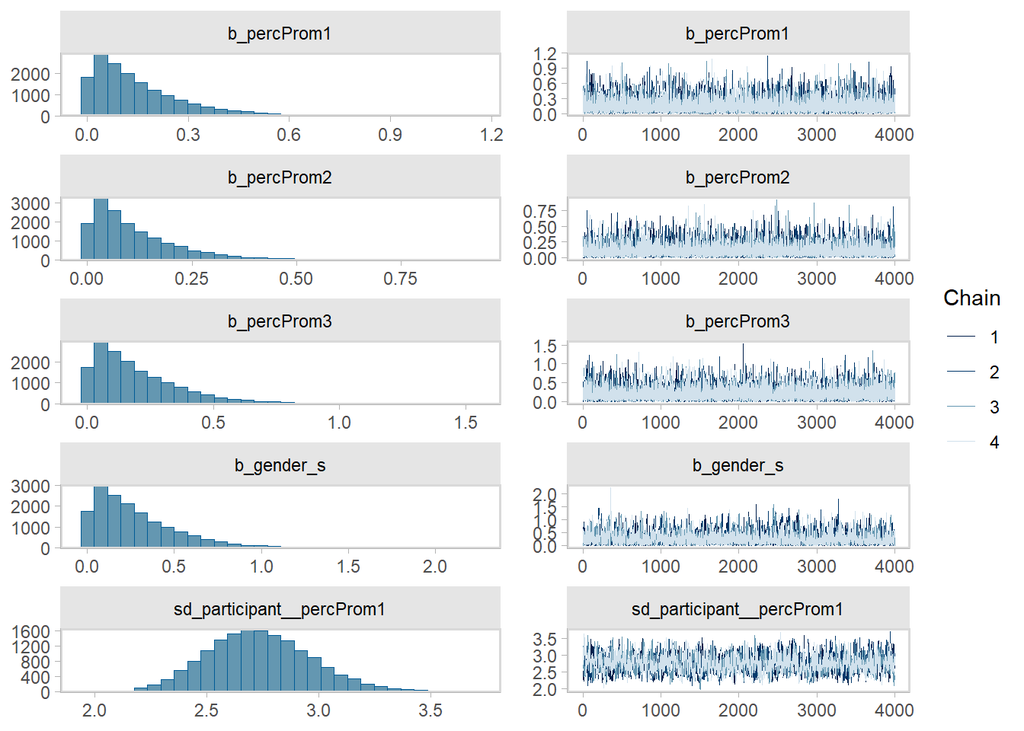

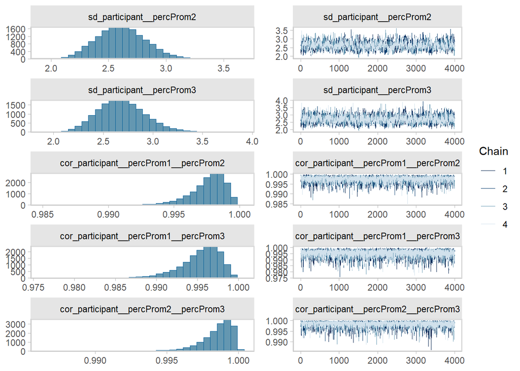

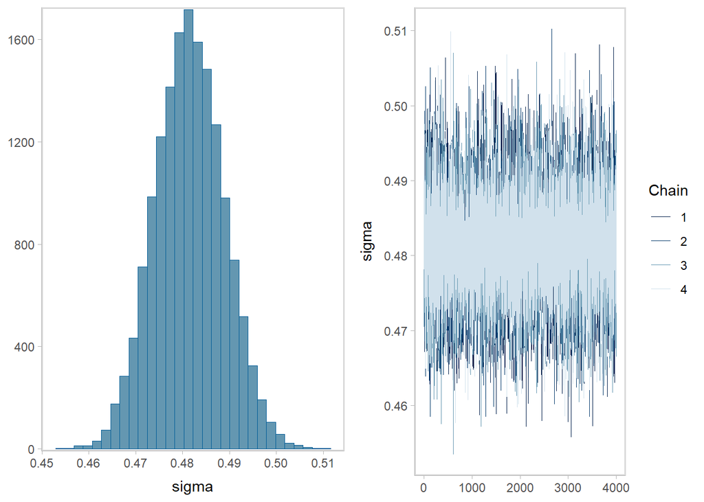

Posterior predictive check.

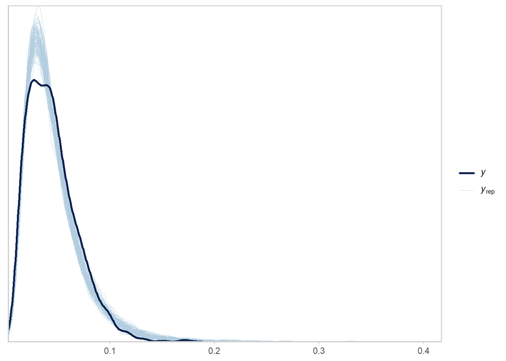

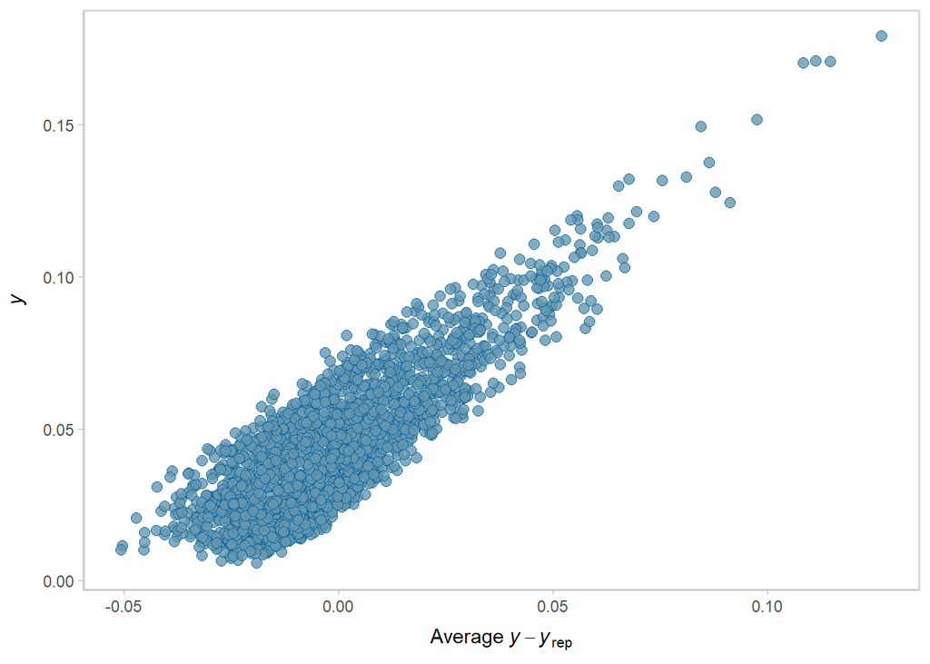

Extract samples.

| variable | mean | median | sd | mad | q5 | q95 | rhat | ess_bulk | ess_tail |
| --- | --- | --- | --- | --- | --- | --- | --- | --- | --- |
| b_percProm1 | 0.1563218 | 0.11433766 | 0.1449485 | 0.11448936 | 0.008696195 | 0.4500050 | 1.000051 | 15015.423 | 8945.299 |
| b_percProm2 | 0.1138807 | 0.08155211 | 0.1072709 | 0.08223557 | 0.006141207 | 0.3247550 | 1.000287 | 16910.465 | 8872.638 |
| b_percProm3 | 0.2010767 | 0.15114659 | 0.1792355 | 0.15005345 | 0.011948508 | 0.5619301 | 1.000263 | 12133.901 | 7815.606 |
| b_gender_s | 0.2797016 | 0.21657474 | 0.2435454 | 0.20913834 | 0.017139383 | 0.7606872 | 1.000748 | 3024.347 | 3170.183 |
| exp_b_percProm1 | 1.1825994 | 1.12113062 | 0.1954257 | 0.12634198 | 1.008734116 | 1.5683200 | 1.000039 | 15015.423 | 8945.299 |
| exp_b_percProm2 | 1.1275121 | 1.08496975 | 0.1338959 | 0.08818410 | 1.006160103 | 1.3836916 | 1.000287 | 16910.465 | 8872.638 |
| exp_b_percProm3 | 1.2444662 | 1.16316716 | 0.2601453 | 0.17042590 | 1.012020177 | 1.7540548 | 1.000254 | 12133.901 | 7815.606 |

Check conditional effect.

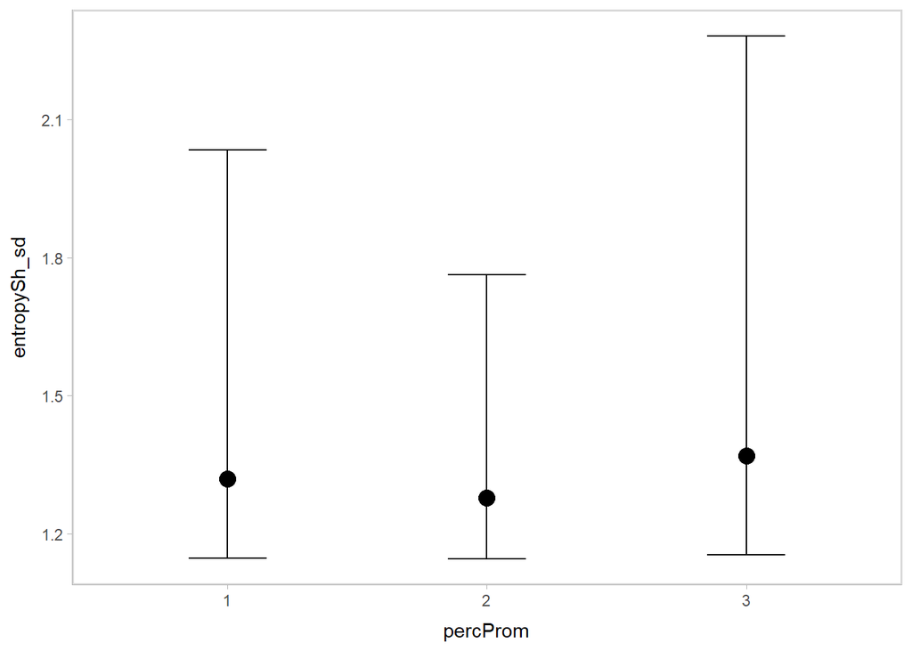

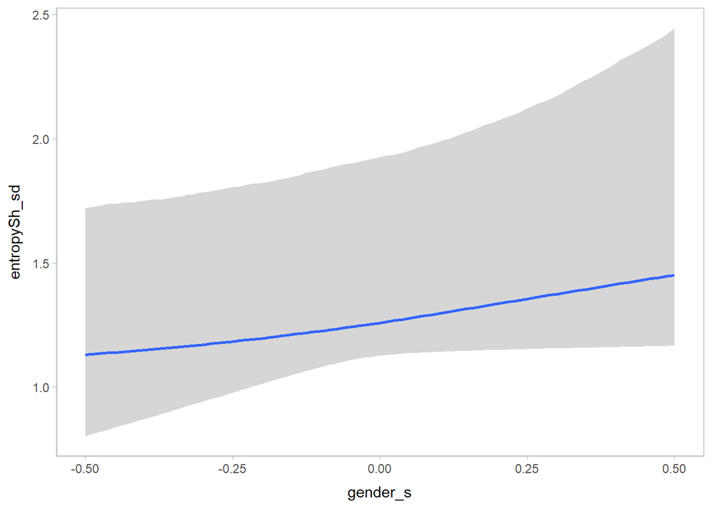

| percProm | entropySh_sd | gender_s | participant | cond__ | effect1__ | estimate__ | se__ | lower__ | upper__ |
| --- | --- | --- | --- | --- | --- | --- | --- | --- | --- |
| 1 | 0.04494556 | 0.1565702 | NA | 1 | 1 | 1.318984 | 0.1632499 | 1.147109 | 2.034441 |
| 2 | 0.04494556 | 0.1565702 | NA | 1 | 2 | 1.278113 | 0.1198589 | 1.145896 | 1.763160 |
| 3 | 0.04494556 | 0.1565702 | NA | 1 | 3 | 1.369957 | 0.2064331 | 1.154801 | 2.281848 |

Compare conditional effects to raw values.

| percProm | avg_entropySh_sd |
| --- | --- |
| 1 | 0.03905282 |
| 2 | 0.04568905 |
| 3 | 0.04905399 |

```
##     Min.  1st Qu.   Median     Mean  3rd Qu.     Max.     NA's
## 0.005668 0.026568 0.041266 0.044946 0.058181 0.179098        1
```

##### 4.1.5.3.1 Effect comparison

```
##  percProm emmean lower.HPD upper.HPD
##  1          1.14         1      1.60
##  2          1.11         1      1.42
##  3          1.19         1      1.78
##
## Results are averaged over the levels of: gender_s
## Point estimate displayed: median
## HPD interval probability: 0.95
```

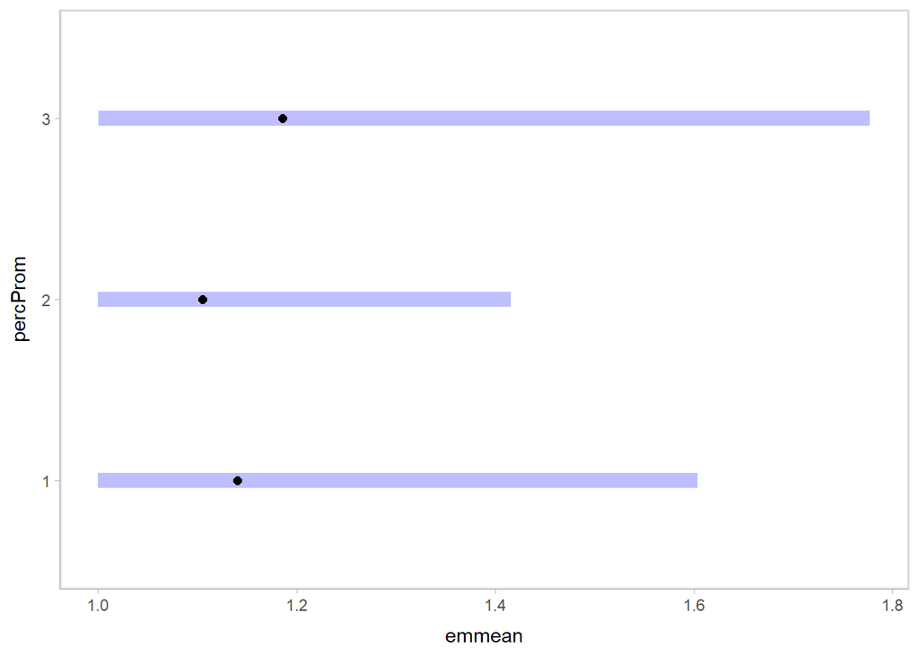

```
##  contrast              estimate lower.HPD upper.HPD
##  percProm1 - percProm2   0.0278    -0.385     0.573
##  percProm1 - percProm3  -0.0318    -0.782     0.592
##  percProm2 - percProm3  -0.0633    -0.736     0.387
##
## Results are averaged over the levels of: gender_s
## Point estimate displayed: median
## HPD interval probability: 0.95
```

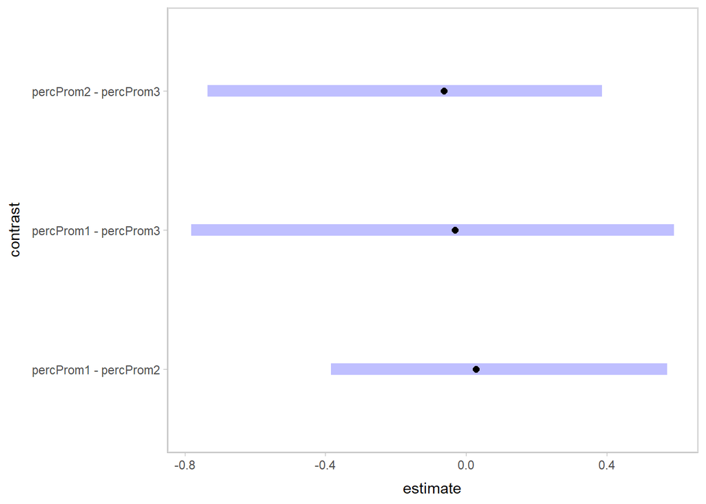

If the comparison includes 0, the contrast is not reliably different.

##### 4.1.5.3.2 Hypothesis testing

| Comparison | Estimate | Est.Error | CI.Lower | CI.Upper | Post.Prob | Star |
| --- | --- | --- | --- | --- | --- | --- |
| diff_1_2 | -0.055 | 0.229 | -0.595 | 0.349 | 58.59 |  |
| diff_1_3 | 0.062 | 0.324 | -0.555 | 0.805 | 57.01 |  |
| diff_2_3 | 0.117 | 0.280 | -0.314 | 0.821 | 65.93 |  |

- **diff_1_2:** Estimate = -0.055 [-0.595, 0.349], Posterior Probability = 58.6%; There is no strong evidence for a difference between `percProm1` and `percProm2`. The credible interval includes zero, and the posterior probability is close to chance, making the difference unreliable.
- **diff_1_3:** Estimate = 0.062 [-0.555, 0.805], Posterior Probability = 57.0%; There is weak evidence suggesting that `entropySh_sd` at `percProm3` is higher than at `percProm1`. However, the wide credible interval and posterior probability indicate a lack of reliability for this difference.
- **diff_2_3:** Estimate = 0.117 [-0.314, 0.821], Posterior Probability = 65.9%; There is weak evidence that `entropySh_sd` at `percProm3` is higher than at `percProm2`. This difference remains inconclusive, given the wide credible interval and posterior probability below 95%.

**Overall Implications:**

- **Trend:** There is no strong or consistent evidence of significant differences between perceived prominence levels for `entropySh_sd`. The posterior probabilities and wide credible intervals suggest that any potential differences are uncertain and should be interpreted with caution.

##### 4.1.5.3.3 Plot fixef

Visualize the (non-)linearity of the effect with a violin plot of the posteriors for each prominence level and a GAMM overlaid on top.

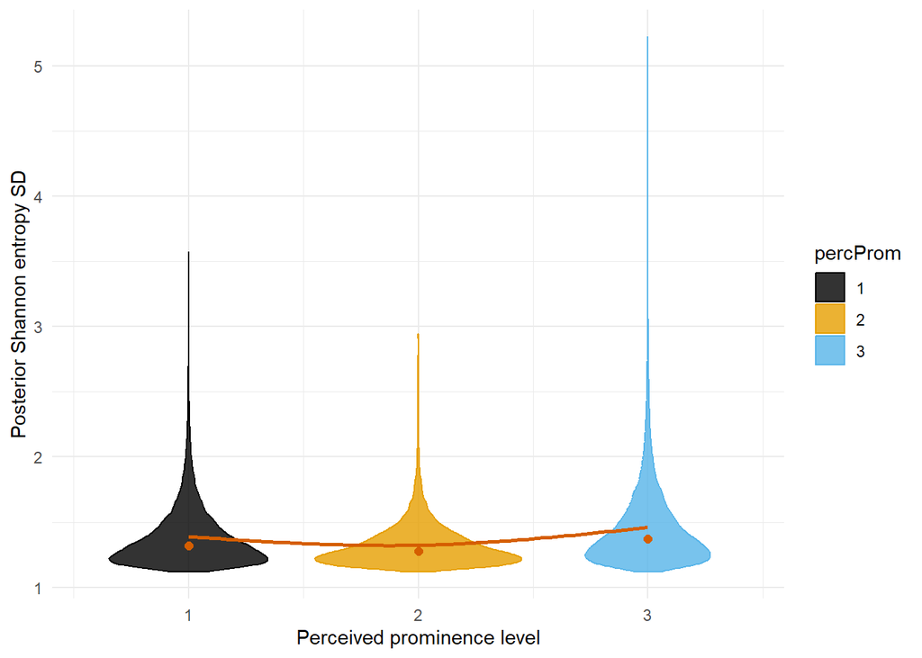

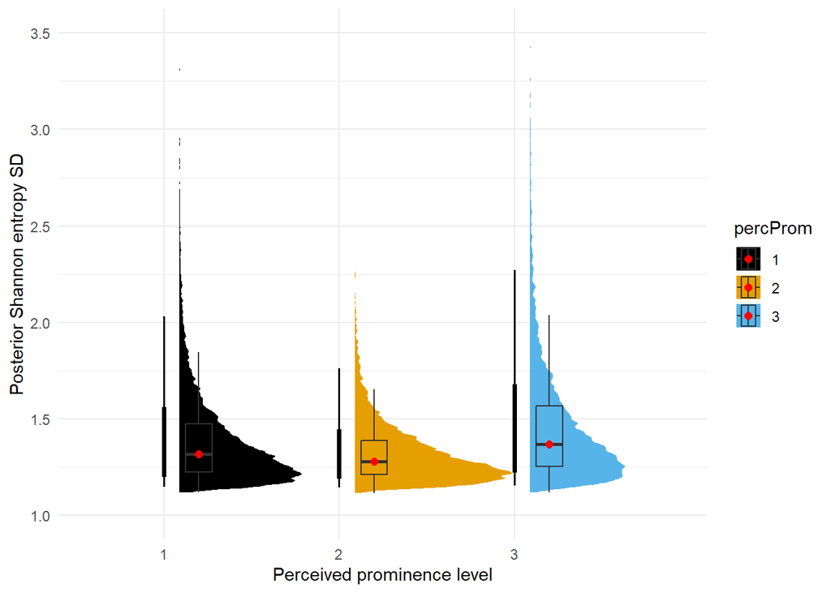

#### 4.1.5.4 Group-level effects

First, get a general overview.

| Random Effect | Estimate | Est.Error | Q2.5 | Q97.5 |
| --- | --- | --- | --- | --- |
| percProm1 | 2.735959 | 0.2343094 | 2.311515 | 3.229496 |
| percProm2 | 2.611741 | 0.2136138 | 2.224363 | 3.051975 |
| percProm3 | 2.687157 | 0.2407909 | 2.254013 | 3.198039 |

- **percProm1:** The estimated standard deviation is 2.736 (95% CrI: 2.312 to 3.229), indicating considerable variability in participants’ responses at `percProm1`.
- **percProm2:** The estimated standard deviation is 2.612 (95% CrI: 2.224 to 3.052), suggesting moderate variability at `percProm2`, which is slightly lower than at `percProm1`.
- **percProm3:** The estimated standard deviation is 2.687 (95% CrI: 2.254 to 3.198), showing similar variability to `percProm1`, though with a slightly wider credible interval, suggesting some uncertainty in participants’ responses at this level.

These results highlight that there is considerable participant-level variability in `entropySh_sd` across perceived prominence levels, with relatively high variability observed at each level.

Extract samples in interpretable units. Then, plot them so that we can see how each participant uses the levels of percProm.

| participant | percProm | gender_s | .row | .epred | .lower | .upper | .width | .point | .interval |
| --- | --- | --- | --- | --- | --- | --- | --- | --- | --- |
| 1 | 1 | 0.1563 | 1 | 0.07672130 | 0.05638314 | 0.12453144 | 0.95 | median | qi |
| 1 | 2 | 0.1563 | 2 | 0.07487889 | 0.06060875 | 0.11850377 | 0.95 | median | qi |
| 1 | 3 | 0.1563 | 3 | 0.07893125 | 0.05988423 | 0.12666117 | 0.95 | median | qi |
| 2 | 1 | 0.1563 | 4 | 0.03673326 | 0.02635972 | 0.04845268 | 0.95 | median | qi |
| 2 | 2 | 0.1563 | 5 | 0.04924393 | 0.03827240 | 0.05813284 | 0.95 | median | qi |
| 2 | 3 | 0.1563 | 6 | 0.04917269 | 0.03686125 | 0.06245319 | 0.95 | median | qi |
| 3 | 1 | 0.1563 | 7 | 0.05288848 | 0.03871244 | 0.06862203 | 0.95 | median | qi |
| 3 | 2 | 0.1563 | 8 | 0.05862822 | 0.04561561 | 0.06891875 | 0.95 | median | qi |
| 3 | 3 | 0.1563 | 9 | 0.05535504 | 0.04195215 | 0.06834014 | 0.95 | median | qi |
| 4 | 1 | 0.1563 | 10 | 0.05778261 | 0.04310707 | 0.07379265 | 0.95 | median | qi |

[output cut: 95 more lines]

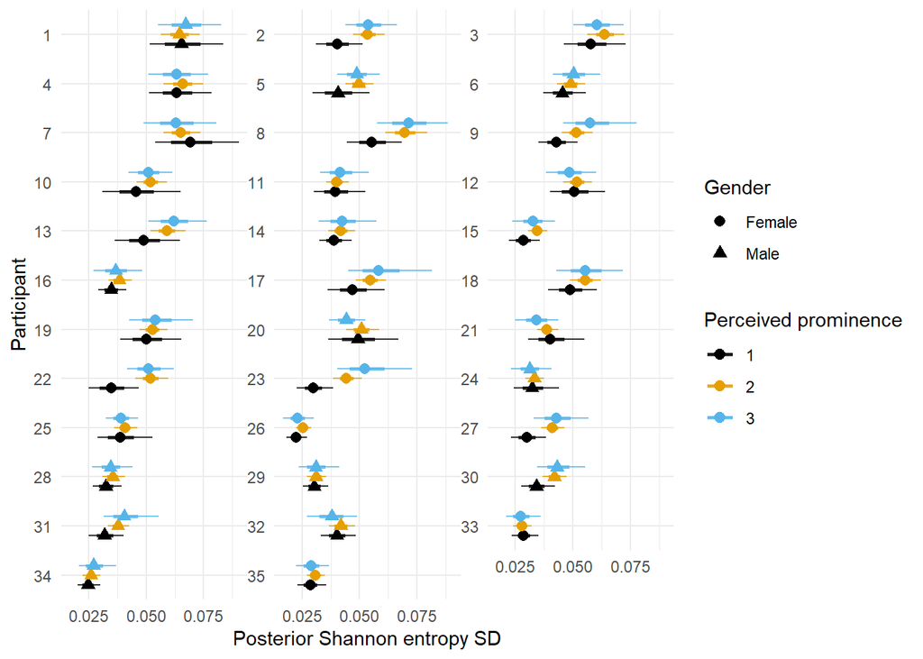

First, we extract individual draws. Here, if the CrI encompasses 0, the participant does not differ from the overall behavior on this percProm. Then, we plot random effects for each participant and percProm level on the model scale, representing deviations from the fixed effects.

| participant | percProm | r_participant | .lower | .upper | .width | .point | .interval |
| --- | --- | --- | --- | --- | --- | --- | --- |
| 1 | percProm1 | -2.855959 | -3.297213 | -2.438044 | 0.95 | median | qi |
| 1 | percProm2 | -2.835885 | -3.184121 | -2.468965 | 0.95 | median | qi |
| 1 | percProm3 | -2.863539 | -3.388127 | -2.426921 | 0.95 | median | qi |
| 2 | percProm1 | -3.599056 | -4.173941 | -3.243226 | 0.95 | median | qi |
| 2 | percProm2 | -3.273084 | -3.695159 | -3.027241 | 0.95 | median | qi |
| 2 | percProm3 | -3.349760 | -3.910148 | -3.005611 | 0.95 | median | qi |
| 3 | percProm1 | -3.232552 | -3.789330 | -2.893392 | 0.95 | median | qi |
| 3 | percProm2 | -3.096208 | -3.517783 | -2.860237 | 0.95 | median | qi |
| 3 | percProm3 | -3.234295 | -3.791382 | -2.909634 | 0.95 | median | qi |
| 4 | percProm1 | -3.144758 | -3.675016 | -2.818005 | 0.95 | median | qi |

[output cut: 95 more lines]

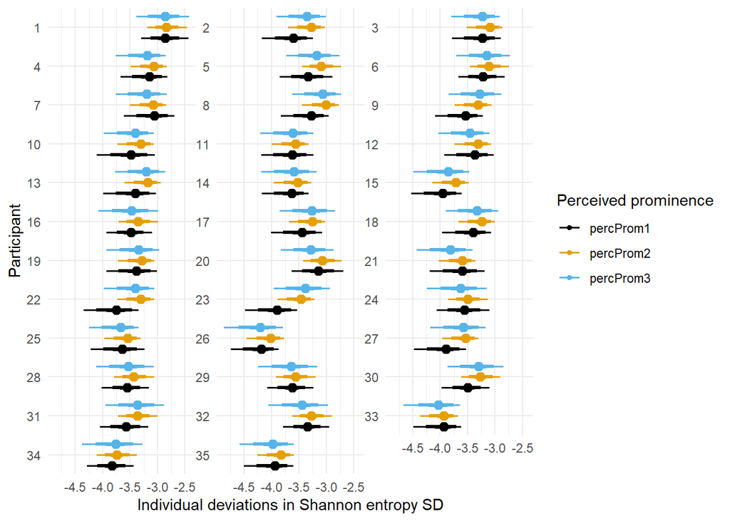

### 4.1.6 Flux median (post-tonic)

#### 4.1.6.1 Priors

| prior | class | coef | group | resp | dpar | nlpar | lb | ub | source |
| --- | --- | --- | --- | --- | --- | --- | --- | --- | --- |
|  | b |  |  |  |  |  |  |  | default |
|  | b | gender_s |  |  |  |  |  |  | default |
|  | b | percProm1 |  |  |  |  |  |  | default |
|  | b | percProm2 |  |  |  |  |  |  | default |
|  | b | percProm3 |  |  |  |  |  |  | default |
| lkj(1) | cor |  |  |  |  |  |  |  | default |
|  | cor |  | participant |  |  |  |  |  | default |
| gamma(0.01, 0.01) | phi |  |  |  |  |  | 0 |  | default |
| student_t(3, 0, 2.5) | sd |  |  |  |  |  | 0 |  | default |
|  | sd |  | participant |  |  |  |  |  | default |

[output cut: 4 more lines]

#### 4.1.6.2 Model

Calculate R².

```
##      Estimate   Est.Error       Q2.5      Q97.5
## R2 0.02975889 0.003809218 0.02285575 0.03776843
```

An R² of approximately 0.03 suggests a **very low fit**. This value indicates that the model explains only about **3% of the variance** in the dependent variable `flux_medianPost`. In other words, nearly all of the variability in `flux_medianPost` is unaccounted for by the predictors in the model. The 95% credible interval, ranging from **2.3% to 3.8%**, confirms the minimal explanatory power of the model, indicating high uncertainty in the relationship between the predictors and the response variable.

#### 4.1.6.3 Fixed effects

Let’s check how it looks like.

```
##  Family: zero_inflated_beta
##   Links: mu = logit; phi = identity; zi = identity
## Formula: flux_medianPost ~ 0 + percProm + gender_s + (0 + percProm | participant)
##    Data: data_prepost_cat (Number of observations: 1995)
##   Draws: 4 chains, each with iter = 8000; warmup = 4000; thin = 1;
##          total post-warmup draws = 16000
##
## Multilevel Hyperparameters:
## ~participant (Number of levels: 35)
##                          Estimate Est.Error l-95% CI u-95% CI Rhat Bulk_ESS
## sd(percProm1)                3.19      0.27     2.70     3.78 1.01     1259
## sd(percProm2)                2.88      0.22     2.48     3.35 1.01      933
## sd(percProm3)                3.02      0.27     2.54     3.61 1.00     1492
## cor(percProm1,percProm2)     1.00      0.00     0.99     1.00 1.00     5065
## cor(percProm1,percProm3)     0.99      0.01     0.98     1.00 1.00     2878
## cor(percProm2,percProm3)     0.99      0.00     0.98     1.00 1.00     6131
##                          Tail_ESS
## sd(percProm1)                2297
## sd(percProm2)                2050
## sd(percProm3)                2780
## cor(percProm1,percProm2)     8158
## cor(percProm1,percProm3)     6586
## cor(percProm2,percProm3)    10528
##
## Regression Coefficients:
##           Estimate Est.Error l-95% CI u-95% CI Rhat Bulk_ESS Tail_ESS
## percProm1     0.24      0.22     0.01     0.81 1.00    11696     8382
## percProm2     0.10      0.10     0.00     0.37 1.00    15242     8027
## percProm3     0.27      0.25     0.01     0.94 1.00    11329     8841
## gender_s      0.22      0.21     0.01     0.77 1.00     4738     4152
##
## Further Distributional Parameters:
##     Estimate Est.Error l-95% CI u-95% CI Rhat Bulk_ESS Tail_ESS
## phi    18.82      0.80    17.27    20.41 1.00    22417    10691
## zi      0.00      0.00     0.00     0.00 1.00    20690     9102
##
## Draws were sampled using sampling(NUTS). For each parameter, Bulk_ESS
## and Tail_ESS are effective sample size measures, and Rhat is the potential
## scale reduction factor on split chains (at convergence, Rhat = 1).
```

```
##            Estimate Est.Error        Q2.5     Q97.5
## percProm1 0.2356616 0.2208363 0.006266123 0.8114322
## percProm2 0.1000393 0.1004706 0.002549701 0.3706760
## percProm3 0.2709642 0.2494974 0.007335838 0.9388155
## gender_s  0.2172763 0.2066923 0.006234345 0.7657176
```

It shows a decrease from 1 to 2, and then an increase from 2 to 3. 3 is more or less as high as 1.

Diagnostic plots.

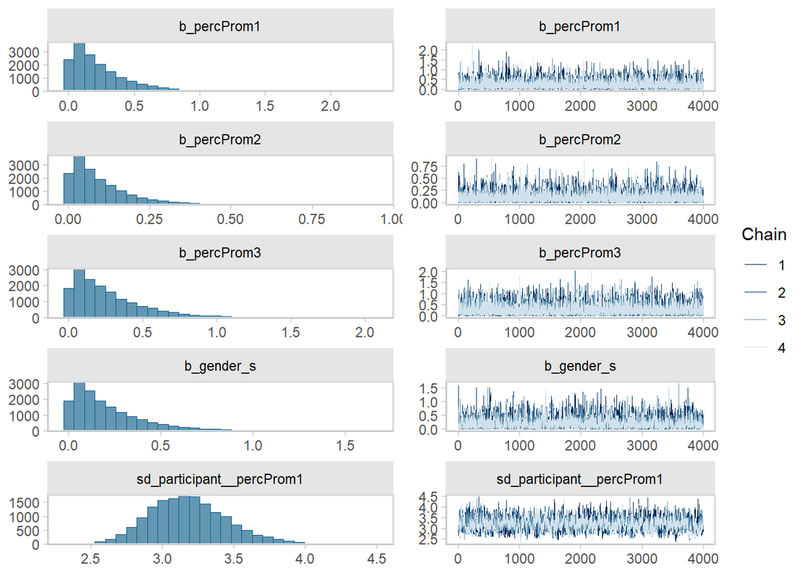

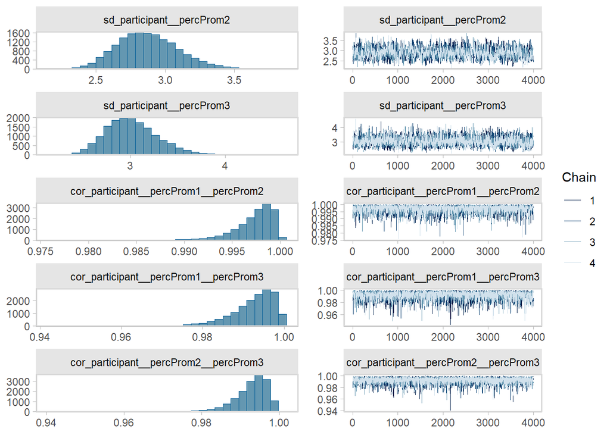

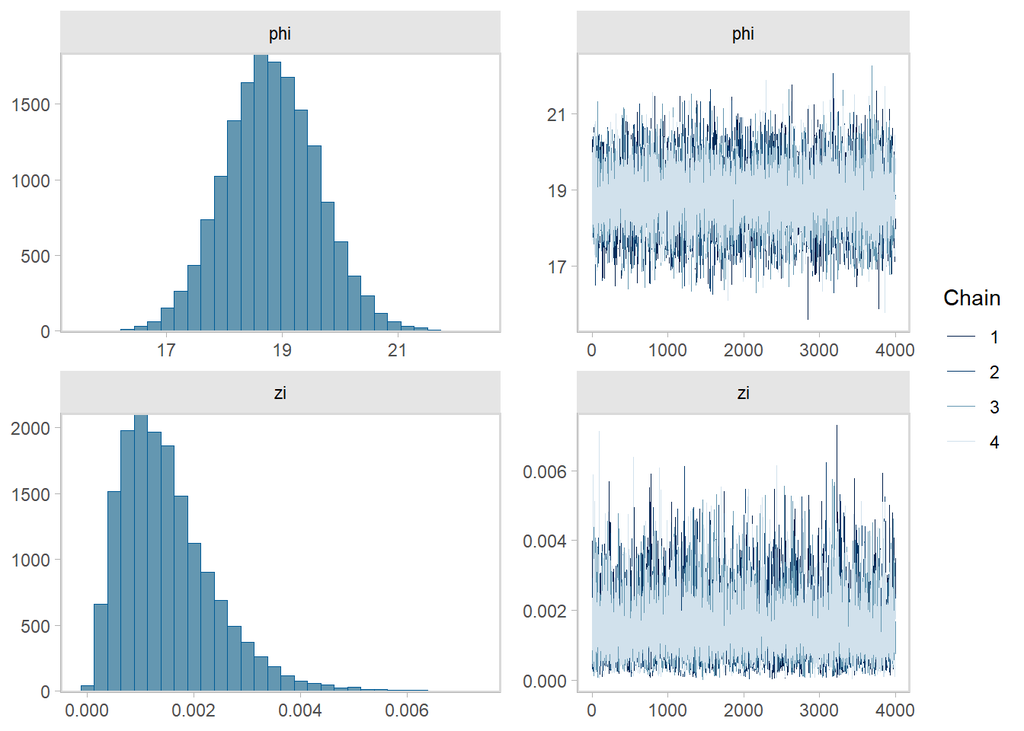

Posterior predictive check.

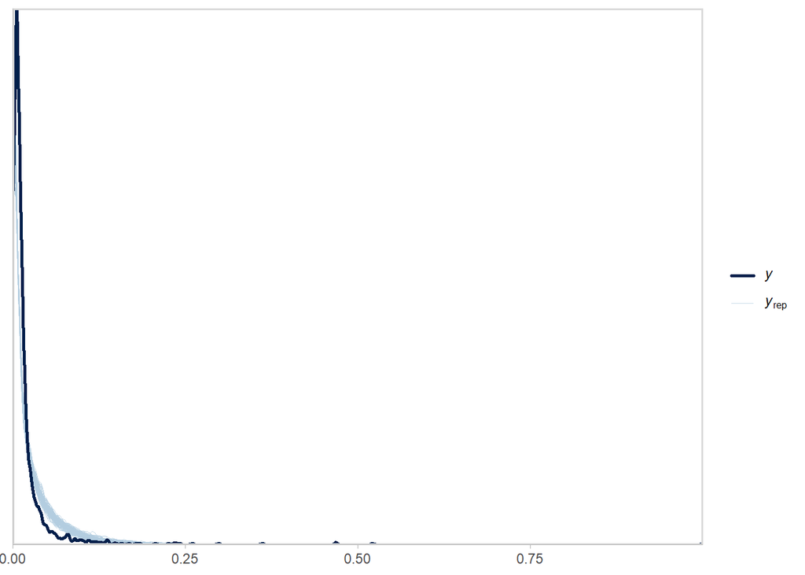

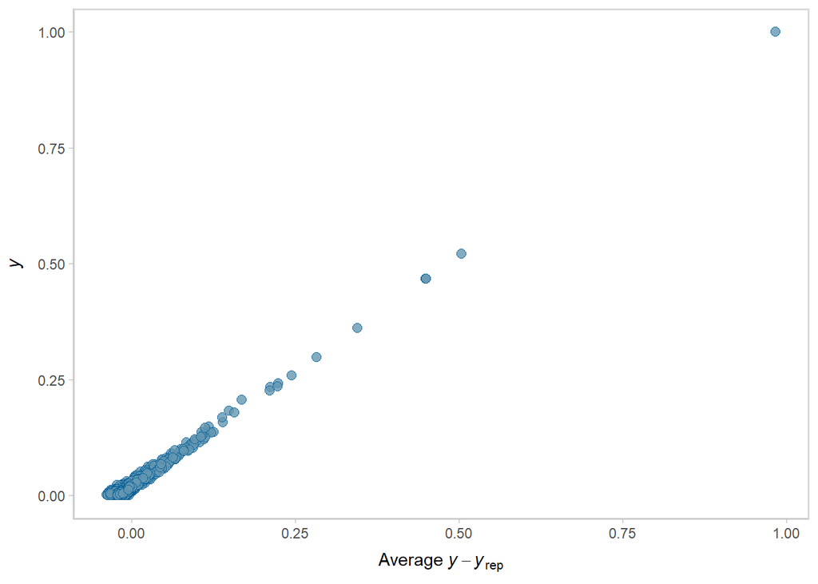

Extract samples.

| variable | mean | median | sd | mad | q5 | q95 | rhat | ess_bulk | ess_tail |
| --- | --- | --- | --- | --- | --- | --- | --- | --- | --- |
| b_percProm1 | 0.2356616 | 0.17124372 | 0.2208363 | 0.17433238 | 0.01246793 | 0.6747126 | 1.000423 | 11695.500 | 8381.666 |
| b_percProm2 | 0.1000393 | 0.06887127 | 0.1004706 | 0.07138451 | 0.00529005 | 0.3022158 | 1.000266 | 15241.651 | 8027.382 |
| b_percProm3 | 0.2709642 | 0.20017911 | 0.2494974 | 0.20153695 | 0.01513641 | 0.7730265 | 1.000063 | 11329.024 | 8841.160 |
| b_gender_s | 0.2172763 | 0.15510553 | 0.2066923 | 0.15673575 | 0.01224163 | 0.6329333 | 1.000664 | 4737.997 | 4152.471 |

Check conditional effect.

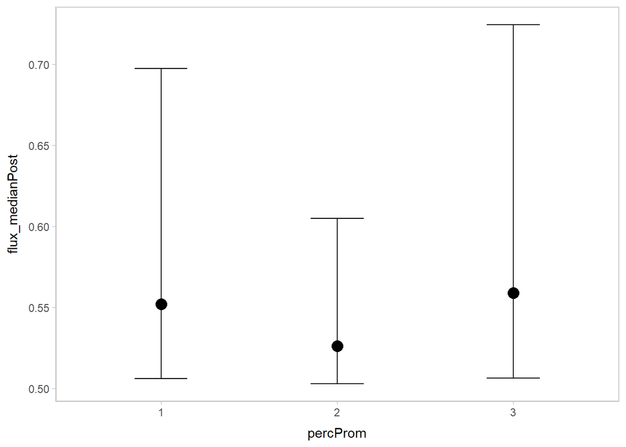

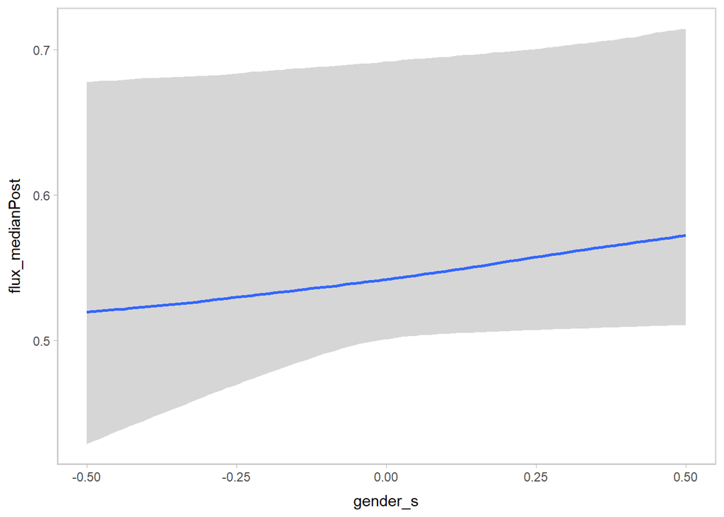

| percProm | flux_medianPost | gender_s | participant | cond__ | effect1__ | estimate__ | se__ | lower__ | upper__ |
| --- | --- | --- | --- | --- | --- | --- | --- | --- | --- |
| 1 | 0.01711987 | 0.1706767 | NA | 1 | 1 | 0.5520146 | 0.04284421 | 0.5057918 | 0.6974790 |
| 2 | 0.01711987 | 0.1706767 | NA | 1 | 2 | 0.5261486 | 0.02095471 | 0.5028787 | 0.6049655 |
| 3 | 0.01711987 | 0.1706767 | NA | 1 | 3 | 0.5589744 | 0.04947262 | 0.5063184 | 0.7246223 |

Compare conditional effects to raw values.

| percProm | avg_flux_medianPost |
| --- | --- |
| 1 | 0.01936559 |
| 2 | 0.01602056 |
| 3 | 0.02028857 |

```
##    Min. 1st Qu.  Median    Mean 3rd Qu.    Max.    NA's
## 0.00000 0.00410 0.00838 0.01712 0.01652 0.99998     251
```

##### 4.1.6.3.1 Effect comparison

```
##  percProm emmean lower.HPD upper.HPD
##  1        0.1712  5.01e-05     0.675
##  2        0.0689  1.89e-05     0.302
##  3        0.2002  2.20e-05     0.773
##
## Results are averaged over the levels of: gender_s
## Point estimate displayed: median
## Results are given on the logit (not the response) scale.
## HPD interval probability: 0.95
```

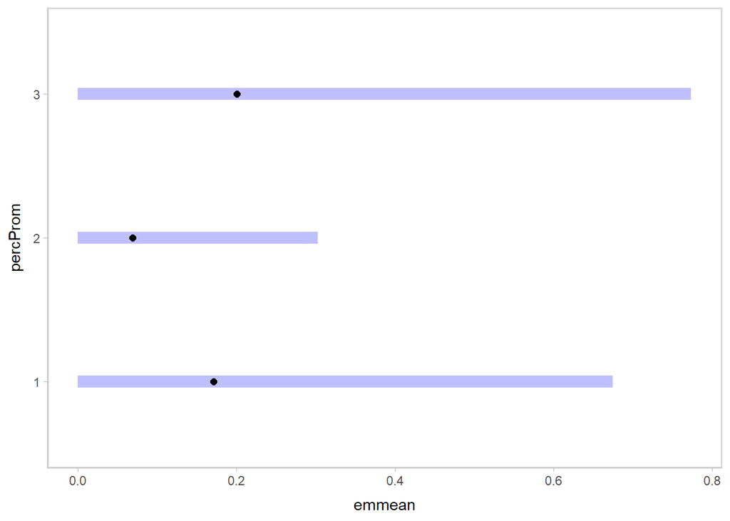

```
##  contrast              estimate lower.HPD upper.HPD
##  percProm1 - percProm2   0.0858    -0.287     0.673
##  percProm1 - percProm3  -0.0182    -0.725     0.658
##  percProm2 - percProm3  -0.1110    -0.784     0.270
##
## Results are averaged over the levels of: gender_s
## Point estimate displayed: median
## Results are given on the log odds ratio (not the response) scale.
## HPD interval probability: 0.95
```

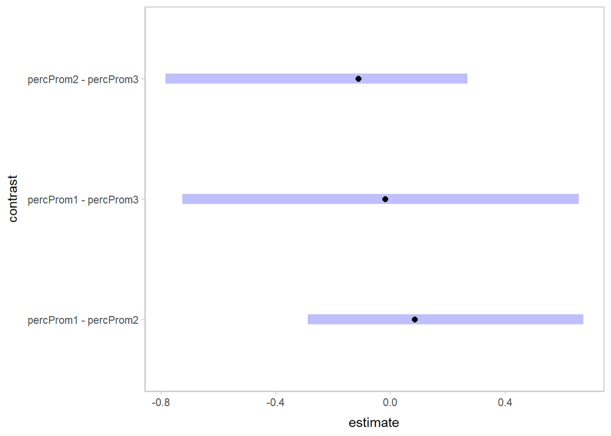

If the comparison includes 0, the contrast is not reliably different.

##### 4.1.6.3.2 Hypothesis testing

| Comparison | Estimate | Est.Error | CI.Lower | CI.Upper | Post.Prob | Star |
| --- | --- | --- | --- | --- | --- | --- |
| diff_1_2 | -0.136 | 0.243 | -0.734 | 0.249 | 71.39 |  |
| diff_1_3 | 0.035 | 0.330 | -0.627 | 0.763 | 53.48 |  |
| diff_2_3 | 0.171 | 0.269 | -0.232 | 0.850 | 74.38 |  |

**Overall Implications:**

- **Trend:** There is no consistent or strong evidence of significant differences between perceived prominence levels for `flux_medianPost`. The posterior probabilities and wide credible intervals suggest that any potential differences are uncertain and lack reliability.

##### 4.1.6.3.3 Plot fixef

Visualize the (non-)linearity of the effect with a violin plot of the posteriors for each prominence level and a GAMM overlaid on top.

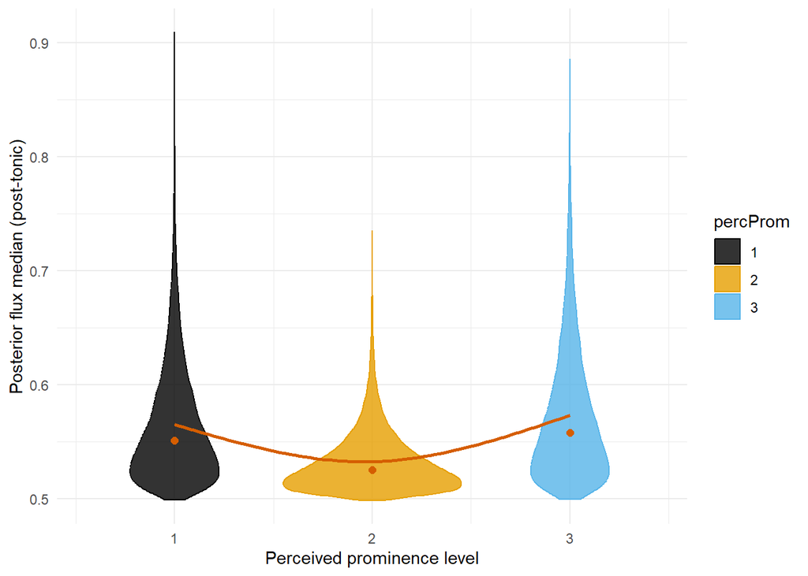

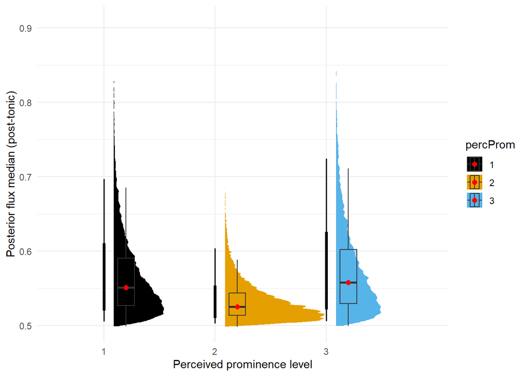

#### 4.1.6.4 Group-level effects

First, get a general overview.

| Random Effect | Estimate | Est.Error | Q2.5 | Q97.5 |
| --- | --- | --- | --- | --- |
| percProm1 | 3.185177 | 0.2745442 | 2.704923 | 3.779631 |
| percProm2 | 2.875007 | 0.2237547 | 2.477077 | 3.352387 |
| percProm3 | 3.015576 | 0.2749453 | 2.540610 | 3.611378 |

- **percProm1:** The estimated standard deviation is 3.185 (95% CrI: 2.705 to 3.780), indicating considerable variability in participants’ responses at `percProm1`.
- **percProm2:** The estimated standard deviation is 2.875 (95% CrI: 2.477 to 3.352), suggesting moderate participant-level variability at `percProm2`, slightly lower than at `percProm1`.
- **percProm3:** The estimated standard deviation is 3.016 (95% CrI: 2.541 to 3.611), showing similar variability to `percProm1` and `percProm2`.

These results highlight substantial participant-level variability in `flux_medianPost` across perceived prominence levels, suggesting that individual differences play a significant role in the responses at each prominence level.

Extract samples in interpretable units. Then, plot them so that we can see how each participant uses the levels of percProm.

| participant | percProm | gender_s | .row | .epred | .lower | .upper | .width | .point | .interval |
| --- | --- | --- | --- | --- | --- | --- | --- | --- | --- |
| 1 | 1 | 0.1563 | 1 | 0.02107807 | 0.012618677 | 0.03724028 | 0.95 | median | qi |
| 1 | 2 | 0.1563 | 2 | 0.02623503 | 0.018743189 | 0.04031486 | 0.95 | median | qi |
| 1 | 3 | 0.1563 | 3 | 0.02697661 | 0.016668916 | 0.04540572 | 0.95 | median | qi |
| 2 | 1 | 0.1563 | 4 | 0.01414590 | 0.008539309 | 0.02186179 | 0.95 | median | qi |
| 2 | 2 | 0.1563 | 5 | 0.01851406 | 0.013267099 | 0.02454325 | 0.95 | median | qi |
| 2 | 3 | 0.1563 | 6 | 0.02285163 | 0.014319239 | 0.03533409 | 0.95 | median | qi |
| 3 | 1 | 0.1563 | 7 | 0.01486824 | 0.009205387 | 0.02184480 | 0.95 | median | qi |
| 3 | 2 | 0.1563 | 8 | 0.02117111 | 0.015195596 | 0.02792158 | 0.95 | median | qi |
| 3 | 3 | 0.1563 | 9 | 0.02262328 | 0.014577517 | 0.03320190 | 0.95 | median | qi |
| 4 | 1 | 0.1563 | 10 | 0.02301049 | 0.015454046 | 0.03360643 | 0.95 | median | qi |

[output cut: 95 more lines]

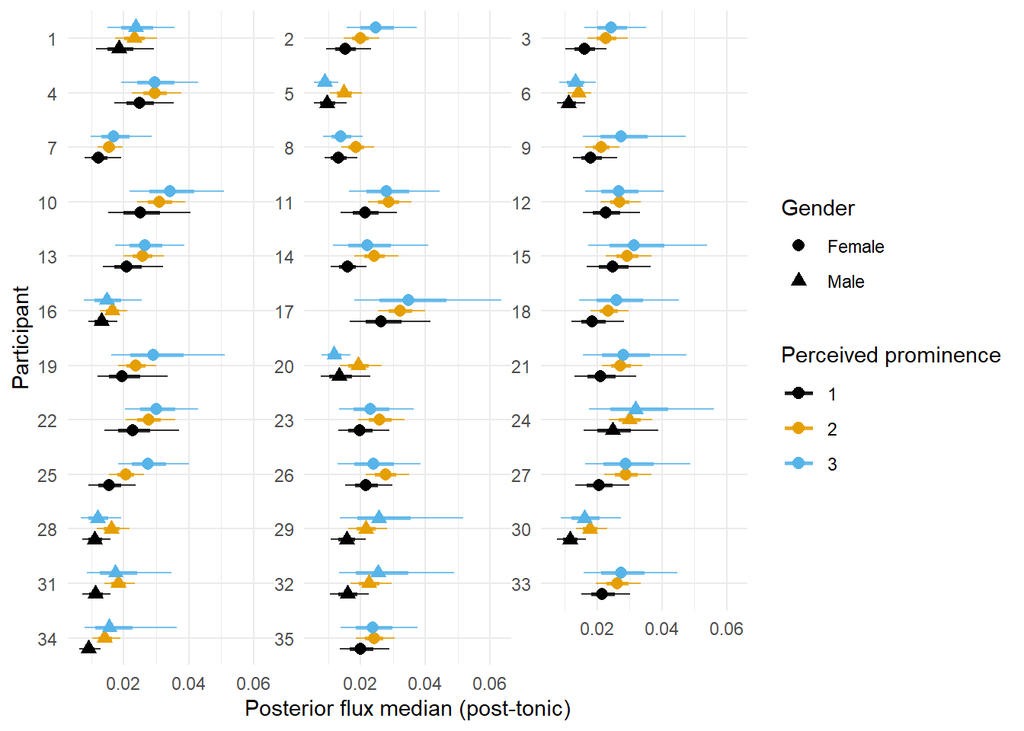

First, we extract individual draws. Here, if the CrI encompasses 0, the participant does not differ from the overall behavior on this percProm. Then, we plot random effects for each participant and percProm level on the model scale, representing deviations from the fixed effects.

| participant | percProm | r_participant | .lower | .upper | .width | .point | .interval |
| --- | --- | --- | --- | --- | --- | --- | --- |
| 1 | percProm1 | -4.078218 | -4.847180 | -3.458652 | 0.95 | median | qi |
| 1 | percProm2 | -3.731934 | -4.135768 | -3.351620 | 0.95 | median | qi |
| 1 | percProm3 | -3.854671 | -4.676336 | -3.264943 | 0.95 | median | qi |
| 2 | percProm1 | -4.487842 | -5.256276 | -3.957871 | 0.95 | median | qi |
| 2 | percProm2 | -4.091058 | -4.581774 | -3.752001 | 0.95 | median | qi |
| 2 | percProm3 | -4.028572 | -4.835624 | -3.459161 | 0.95 | median | qi |
| 3 | percProm1 | -4.442081 | -5.196652 | -3.945255 | 0.95 | median | qi |
| 3 | percProm2 | -3.952606 | -4.447300 | -3.619464 | 0.95 | median | qi |
| 3 | percProm3 | -4.040670 | -4.826436 | -3.530956 | 0.95 | median | qi |
| 4 | percProm1 | -3.994177 | -4.660345 | -3.517028 | 0.95 | median | qi |

[output cut: 95 more lines]

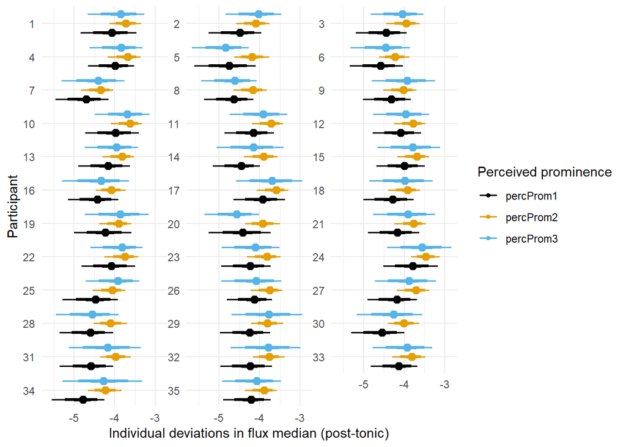

### 4.1.7 Amplitude median (post-tonic)

#### 4.1.7.1 Priors

| prior | class | coef | group | resp | dpar | nlpar | lb | ub | source |
| --- | --- | --- | --- | --- | --- | --- | --- | --- | --- |
|  | b |  |  |  |  |  |  |  | default |
|  | b | gender_s |  |  |  |  |  |  | default |
|  | b | percProm1 |  |  |  |  |  |  | default |
|  | b | percProm2 |  |  |  |  |  |  | default |
|  | b | percProm3 |  |  |  |  |  |  | default |
| lkj(1) | cor |  |  |  |  |  |  |  | default |
|  | cor |  | participant |  |  |  |  |  | default |
| student_t(3, 0, 2.5) | sd |  |  |  |  |  | 0 |  | default |
|  | sd |  | participant |  |  |  |  |  | default |
|  | sd | percProm1 | participant |  |  |  |  |  | default |

[output cut: 3 more lines]

#### 4.1.7.2 Model

Calculate R².

```
##     Estimate  Est.Error      Q2.5    Q97.5
## R2 0.2911882 0.01956155 0.2538602 0.330177
```

An R² of approximately 0.29 suggests a moderate fit, indicating that the model explains about 29.1% of the variance in the dependent variable `ampl_medianPost`. Thus, nearly a third of the variability in `ampl_medianPost` is accounted for by the predictors. The 95% credible interval (25.4% to 33.0%) indicates moderate certainty around this explanatory power.

#### 4.1.7.3 Fixed effects

Let’s check how it looks like.

```
##  Family: lognormal
##   Links: mu = identity; sigma = identity
## Formula: ampl_medianPost ~ 0 + percProm + gender_s + (0 + percProm | participant)
##    Data: data_prepost_cat (Number of observations: 1995)
##   Draws: 4 chains, each with iter = 8000; warmup = 4000; thin = 1;
##          total post-warmup draws = 16000
##
## Multilevel Hyperparameters:
## ~participant (Number of levels: 35)
##                          Estimate Est.Error l-95% CI u-95% CI Rhat Bulk_ESS
## sd(percProm1)                2.42      0.23     2.01     2.91 1.00     1550
## sd(percProm2)                2.18      0.21     1.81     2.63 1.00     1599
## sd(percProm3)                2.36      0.23     1.96     2.87 1.00     1789
## cor(percProm1,percProm2)     0.98      0.01     0.97     0.99 1.00     3695
## cor(percProm1,percProm3)     0.97      0.01     0.93     0.99 1.00     3999
## cor(percProm2,percProm3)     0.99      0.00     0.98     1.00 1.00     6398
##                          Tail_ESS
## sd(percProm1)                3003
## sd(percProm2)                3257
## sd(percProm3)                4104
## cor(percProm1,percProm2)     8031
## cor(percProm1,percProm3)     7858
## cor(percProm2,percProm3)    10916
##
## Regression Coefficients:
##           Estimate Est.Error l-95% CI u-95% CI Rhat Bulk_ESS Tail_ESS
## percProm1     0.12      0.12     0.00     0.44 1.00    16433     9810
## percProm2     0.13      0.12     0.00     0.45 1.00    16053     8821
## percProm3     0.16      0.15     0.00     0.54 1.00    18455    10168
## gender_s      0.23      0.20     0.01     0.76 1.00     5563     5200
##
## Further Distributional Parameters:
##       Estimate Est.Error l-95% CI u-95% CI Rhat Bulk_ESS Tail_ESS
## sigma     0.67      0.01     0.65     0.69 1.00    31800    11661
##
## Draws were sampled using sampling(NUTS). For each parameter, Bulk_ESS
## and Tail_ESS are effective sample size measures, and Rhat is the potential
## scale reduction factor on split chains (at convergence, Rhat = 1).
```

```
##           Estimate Est.Error     Q2.5    Q97.5
## percProm1 1.129096  1.126741 1.003055 1.551368
## percProm2 1.144207  1.127858 1.004314 1.563297
## percProm3 1.173223  1.157395 1.004957 1.718642
## gender_s  1.254358  1.226229 1.006970 2.132875
```

Diagnostic plots.

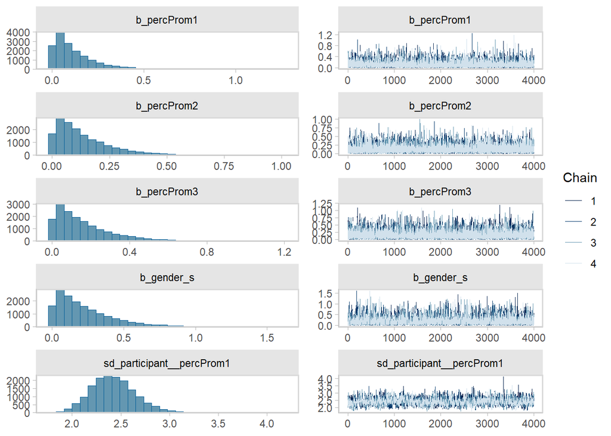

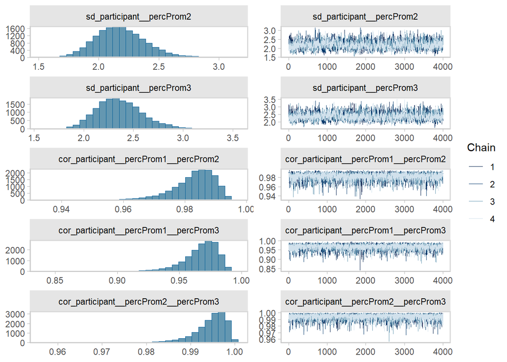

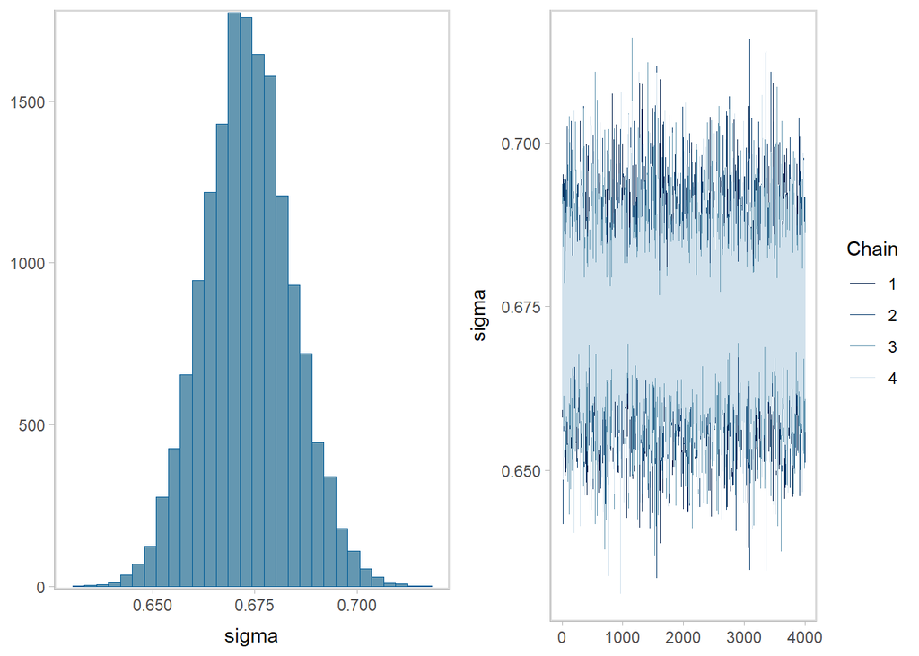

Posterior predictive check.

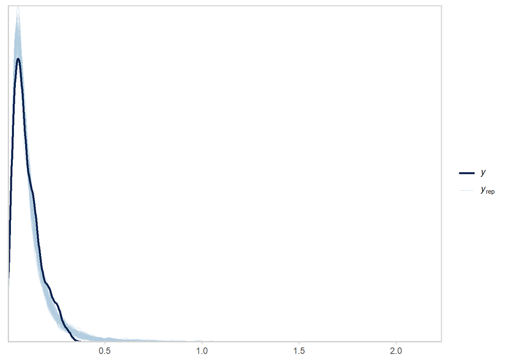

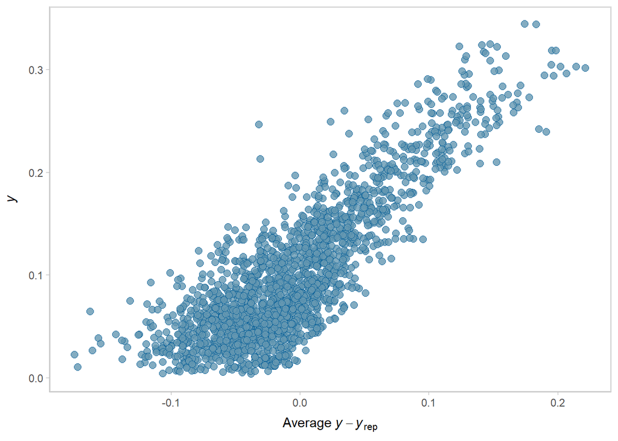

Extract samples.

| variable | mean | median | sd | mad | q5 | q95 | rhat | ess_bulk | ess_tail |
| --- | --- | --- | --- | --- | --- | --- | --- | --- | --- |
| b_percProm1 | 0.1214172 | 0.08486359 | 0.1193292 | 0.08728121 | 0.006557336 | 0.3619834 | 1.0000964 | 16433.293 | 9810.039 |
| b_percProm2 | 0.1347121 | 0.10079166 | 0.1203202 | 0.09783682 | 0.008676627 | 0.3800735 | 1.0003656 | 16052.912 | 8821.002 |
| b_percProm3 | 0.1597547 | 0.11798957 | 0.1461720 | 0.11872704 | 0.009336649 | 0.4541341 | 0.9999866 | 18455.206 | 10167.658 |
| b_gender_s | 0.2266237 | 0.17013905 | 0.2039433 | 0.16845129 | 0.013974416 | 0.6315483 | 1.0000144 | 5563.259 | 5199.564 |
| exp_b_percProm1 | 1.1378427 | 1.08856857 | 0.1548284 | 0.09351226 | 1.006578882 | 1.4361751 | 1.0000854 | 16433.293 | 9810.039 |
| exp_b_percProm2 | 1.1530542 | 1.10604618 | 0.1531724 | 0.10706048 | 1.008714378 | 1.4623921 | 1.0003584 | 16052.912 | 8821.002 |
| exp_b_percProm3 | 1.1868539 | 1.12523237 | 0.1968616 | 0.13103494 | 1.009380371 | 1.5748092 | 0.9999689 | 18455.206 | 10167.658 |

Check conditional effect.

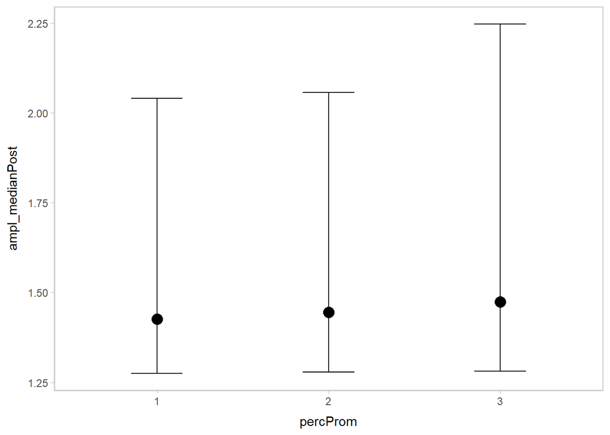

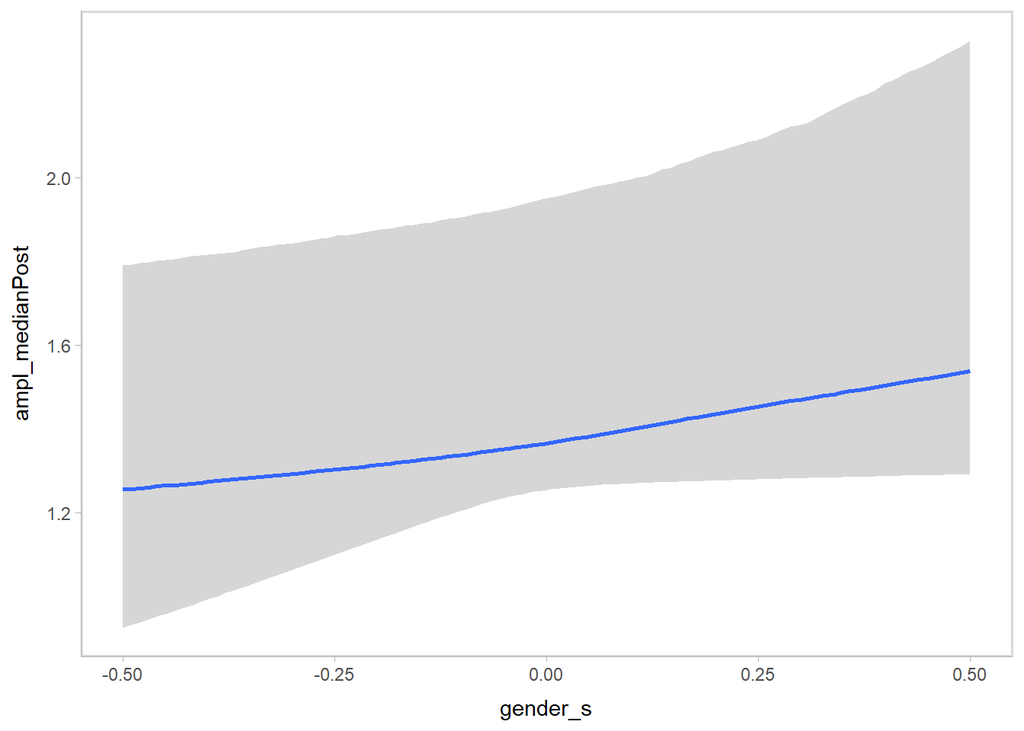

| percProm | ampl_medianPost | gender_s | participant | cond__ | effect1__ | estimate__ | se__ | lower__ | upper__ |
| --- | --- | --- | --- | --- | --- | --- | --- | --- | --- |
| 1 | 0.1000608 | 0.1706767 | NA | 1 | 1 | 1.425635 | 0.1364594 | 1.275174 | 2.040472 |
| 2 | 0.1000608 | 0.1706767 | NA | 1 | 2 | 1.445040 | 0.1513833 | 1.278724 | 2.056877 |
| 3 | 0.1000608 | 0.1706767 | NA | 1 | 3 | 1.473511 | 0.1819940 | 1.280431 | 2.247775 |

Compare conditional effects to raw values.

| percProm | avg_ampl_medianPost |
| --- | --- |
| 1 | 0.07636534 |
| 2 | 0.10923239 |
| 3 | 0.07999749 |

```
##    Min. 1st Qu.  Median    Mean 3rd Qu.    Max.    NA's
## 0.00330 0.04785 0.08166 0.10006 0.13731 0.34435     251
```

##### 4.1.7.3.1 Effect comparison

```
##  percProm emmean lower.HPD upper.HPD
##  1          1.10         1      1.46
##  2          1.12         1      1.49
##  3          1.14         1      1.59
##
## Results are averaged over the levels of: gender_s
## Point estimate displayed: median
## HPD interval probability: 0.95
```

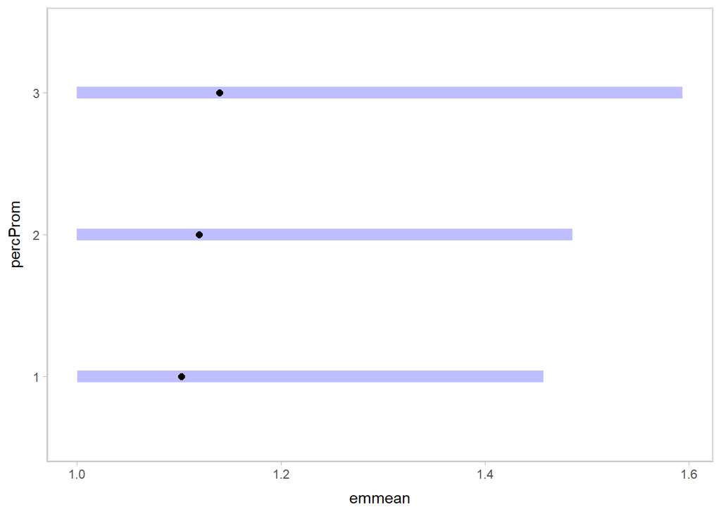

```
##  contrast              estimate lower.HPD upper.HPD
##  percProm1 - percProm2  -0.0118    -0.438     0.448
##  percProm1 - percProm3  -0.0278    -0.596     0.440
##  percProm2 - percProm3  -0.0157    -0.559     0.429
##
## Results are averaged over the levels of: gender_s
## Point estimate displayed: median
## HPD interval probability: 0.95
```

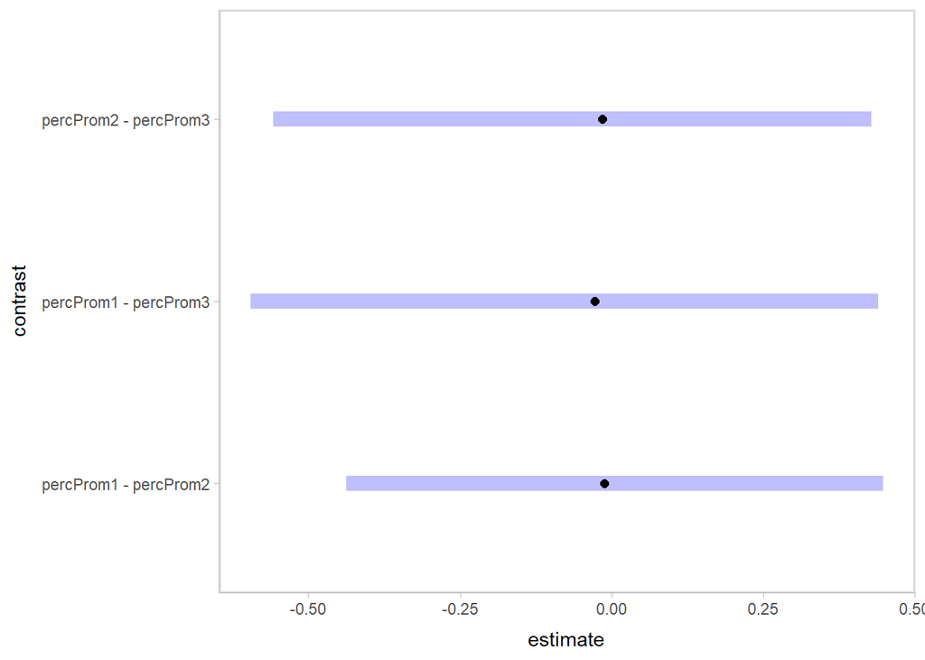

If the comparison includes 0, the contrast is not reliably different.

##### 4.1.7.3.2 Hypothesis testing

| Comparison | Estimate | Est.Error | CI.Lower | CI.Upper | Post.Prob | Star |
| --- | --- | --- | --- | --- | --- | --- |
| diff_1_2 | 0.015 | 0.209 | -0.423 | 0.459 | 54.21 |  |
| diff_1_3 | 0.049 | 0.250 | -0.427 | 0.601 | 58.03 |  |
| diff_2_3 | 0.034 | 0.236 | -0.416 | 0.569 | 54.69 |  |

**Overall Implications:** There is no strong evidence of consistent differences in `ampl_medianPost` across perceived prominence levels, indicating that the predictor levels do not significantly impact `ampl_medianPost`.

##### 4.1.7.3.3 Plot fixef

Visualize the (non-)linearity of the effect with a violin plot of the posteriors for each prominence level and a GAMM overlaid on top.

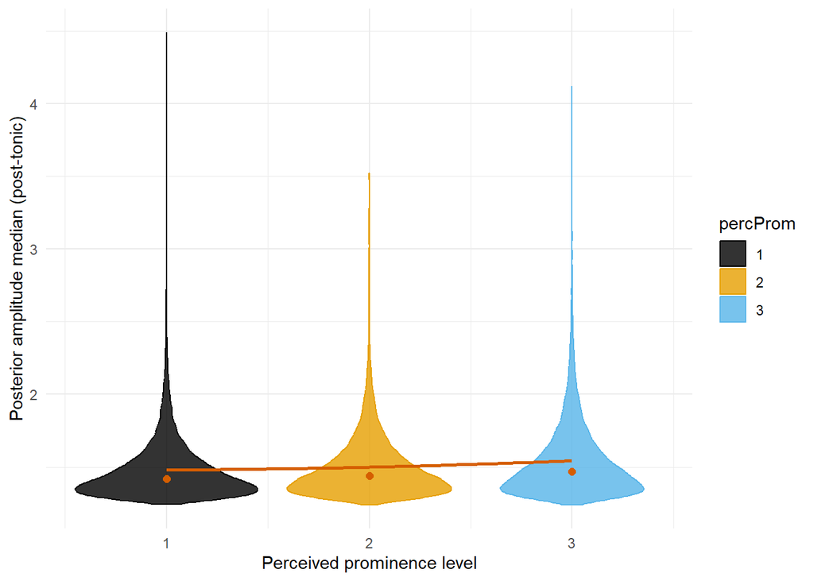

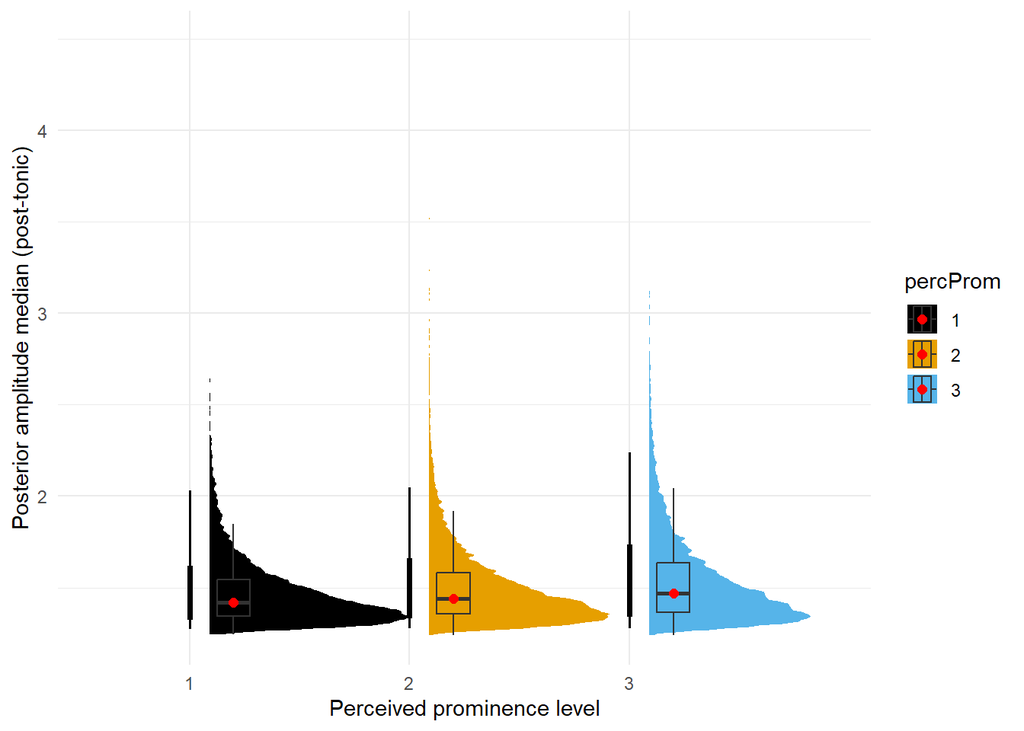

#### 4.1.7.4 Group-level effects

First, get a general overview.

| Random Effect | Estimate | Est.Error | Q2.5 | Q97.5 |
| --- | --- | --- | --- | --- |
| percProm1 | 2.421492 | 0.2281489 | 2.014254 | 2.913129 |
| percProm2 | 2.181440 | 0.2085727 | 1.809070 | 2.629821 |
| percProm3 | 2.362625 | 0.2328660 | 1.962556 | 2.874710 |

- **percProm1:** Estimated SD = 2.421 (95% CrI: 2.014 to 2.913)
- **percProm2:** Estimated SD = 2.181 (95% CrI: 1.809 to 2.630)
- **percProm3:** Estimated SD = 2.363 (95% CrI: 1.963 to 2.875)

Substantial variability is evident across levels, suggesting individual differences in responses to each prominence level.

Extract samples in interpretable units. Then, plot them so that we can see how each participant uses the levels of percProm.

| participant | percProm | gender_s | .row | .epred | .lower | .upper | .width | .point | .interval |
| --- | --- | --- | --- | --- | --- | --- | --- | --- | --- |
| 1 | 1 | 0.1563 | 1 | 0.06905247 | 0.03924137 | 0.12932818 | 0.95 | median | qi |
| 1 | 2 | 0.1563 | 2 | 0.06418087 | 0.04962073 | 0.09623018 | 0.95 | median | qi |
| 1 | 3 | 0.1563 | 3 | 0.04330353 | 0.02983368 | 0.07009423 | 0.95 | median | qi |
| 2 | 1 | 0.1563 | 4 | 0.09206266 | 0.05509494 | 0.15281917 | 0.95 | median | qi |
| 2 | 2 | 0.1563 | 5 | 0.11112064 | 0.08591220 | 0.13773544 | 0.95 | median | qi |
| 2 | 3 | 0.1563 | 6 | 0.08663119 | 0.06151609 | 0.11819194 | 0.95 | median | qi |
| 3 | 1 | 0.1563 | 7 | 0.03874793 | 0.02413782 | 0.06102727 | 0.95 | median | qi |
| 3 | 2 | 0.1563 | 8 | 0.07541280 | 0.05836434 | 0.09357974 | 0.95 | median | qi |
| 3 | 3 | 0.1563 | 9 | 0.06773437 | 0.04927967 | 0.09098448 | 0.95 | median | qi |
| 4 | 1 | 0.1563 | 10 | 0.03038050 | 0.02099866 | 0.04361017 | 0.95 | median | qi |

[output cut: 95 more lines]

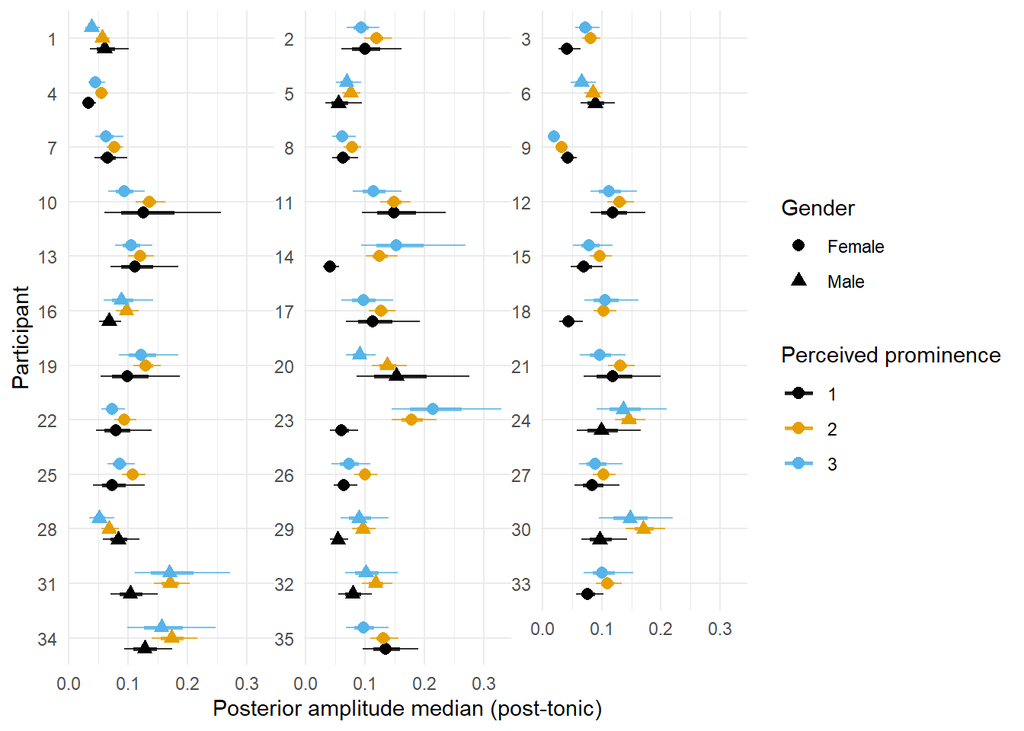

First, we extract individual draws. Here, if the CrI encompasses 0, the participant does not differ from the overall behavior on this percProm. Then, we plot random effects for each participant and percProm level on the model scale, representing deviations from the fixed effects.

| participant | percProm | r_participant | .lower | .upper | .width | .point | .interval |
| --- | --- | --- | --- | --- | --- | --- | --- |
| 1 | percProm1 | -3.047382 | -3.660939 | -2.438135 | 0.95 | median | qi |
| 1 | percProm2 | -3.115527 | -3.513297 | -2.763811 | 0.95 | median | qi |
| 1 | percProm3 | -3.538806 | -4.073586 | -3.074117 | 0.95 | median | qi |
| 2 | percProm1 | -2.760941 | -3.366641 | -2.215436 | 0.95 | median | qi |
| 2 | percProm2 | -2.577606 | -3.025025 | -2.295089 | 0.95 | median | qi |
| 2 | percProm3 | -2.852172 | -3.374817 | -2.478295 | 0.95 | median | qi |
| 3 | percProm1 | -3.620206 | -4.215494 | -3.123397 | 0.95 | median | qi |
| 3 | percProm2 | -2.964519 | -3.425243 | -2.679301 | 0.95 | median | qi |
| 3 | percProm3 | -3.097060 | -3.631670 | -2.722635 | 0.95 | median | qi |
| 4 | percProm1 | -3.866834 | -4.387125 | -3.450842 | 0.95 | median | qi |

[output cut: 95 more lines]

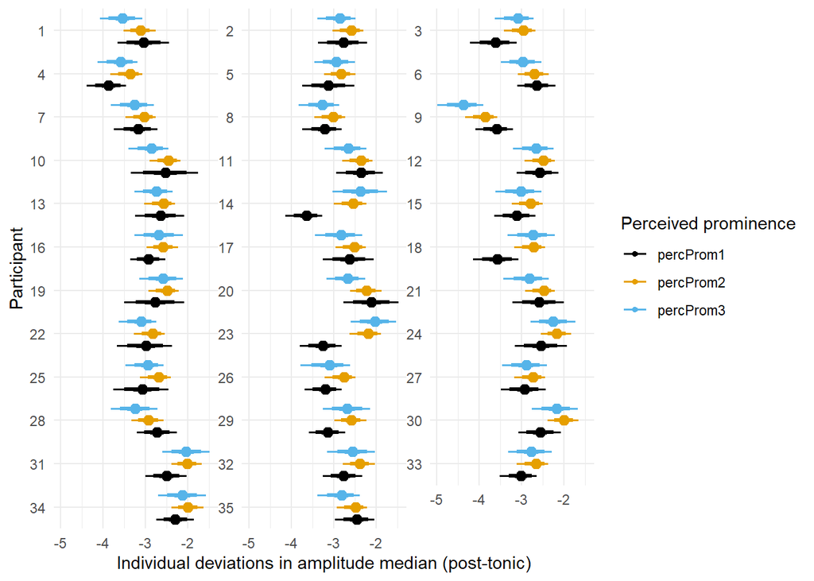

### 4.1.8 Spectral centroid median

#### 4.1.8.1 Priors

| prior | class | coef | group | resp | dpar | nlpar | lb | ub | source |
| --- | --- | --- | --- | --- | --- | --- | --- | --- | --- |
|  | b |  |  |  |  |  |  |  | default |
|  | b | gender_s |  |  |  |  |  |  | default |
|  | b | percProm1 |  |  |  |  |  |  | default |
|  | b | percProm2 |  |  |  |  |  |  | default |
|  | b | percProm3 |  |  |  |  |  |  | default |
| lkj(1) | cor |  |  |  |  |  |  |  | default |
|  | cor |  | participant |  |  |  |  |  | default |
| student_t(3, 0, 2.5) | sd |  |  |  |  |  | 0 |  | default |
|  | sd |  | participant |  |  |  |  |  | default |
|  | sd | percProm1 | participant |  |  |  |  |  | default |

[output cut: 3 more lines]

#### 4.1.8.2 Model

Calculate R².

```
##     Estimate  Est.Error      Q2.5     Q97.5
## R2 0.2441985 0.01455366 0.2157455 0.2728663
```

An R² of approximately 0.24 suggests a modest fit, with the model explaining around 24.4% of the variance in `specCentroid_median`. The 95% credible interval (21.6% to 27.3%) suggests some certainty in this explanatory power, though room for improvement remains.

#### 4.1.8.3 Fixed effects

Let’s check how it looks like.

```
##  Family: lognormal
##   Links: mu = identity; sigma = identity
## Formula: specCentroid_median ~ 0 + percProm + gender_s + (0 + percProm | participant)
##    Data: data_prepost_cat (Number of observations: 2245)
##   Draws: 4 chains, each with iter = 8000; warmup = 4000; thin = 1;
##          total post-warmup draws = 16000
##
## Multilevel Hyperparameters:
## ~participant (Number of levels: 35)
##                          Estimate Est.Error l-95% CI u-95% CI Rhat Bulk_ESS
## sd(percProm1)                0.08      0.01     0.06     0.10 1.00     5503
## sd(percProm2)                0.05      0.01     0.04     0.07 1.00     5568
## sd(percProm3)                0.05      0.01     0.04     0.08 1.00     8711
## cor(percProm1,percProm2)     0.73      0.10     0.49     0.89 1.00     5588
## cor(percProm1,percProm3)     0.57      0.17     0.20     0.85 1.00     7142
## cor(percProm2,percProm3)     0.88      0.09     0.66     0.99 1.00     8314
##                          Tail_ESS
## sd(percProm1)                8775
## sd(percProm2)                8328
## sd(percProm3)               11366
## cor(percProm1,percProm2)     9077
## cor(percProm1,percProm3)    10759
## cor(percProm2,percProm3)    10529
##
## Regression Coefficients:
##           Estimate Est.Error l-95% CI u-95% CI Rhat Bulk_ESS Tail_ESS
## percProm1     5.76      0.01     5.74     5.79 1.00     3827     5694
## percProm2     5.75      0.01     5.73     5.77 1.00     4177     7493
## percProm3     5.72      0.01     5.70     5.74 1.00     5959     8938
## gender_s      0.01      0.01     0.00     0.03 1.00    10159     9555
##
## Further Distributional Parameters:
##       Estimate Est.Error l-95% CI u-95% CI Rhat Bulk_ESS Tail_ESS
## sigma     0.10      0.00     0.09     0.10 1.00    26006    12346
##
## Draws were sampled using sampling(NUTS). For each parameter, Bulk_ESS
## and Tail_ESS are effective sample size measures, and Rhat is the potential
## scale reduction factor on split chains (at convergence, Rhat = 1).
```

```
##             Estimate Est.Error      Q2.5      Q97.5
## percProm1 318.731797  1.014300 309.90812 327.947156
## percProm2 315.211758  1.009359 309.43561 321.095564
## percProm3 304.976537  1.011357 298.23076 311.820390
## gender_s    1.008489  1.007830   1.00025   1.029005
```

It shows a decrease from 1 to 3.

Diagnostic plots.

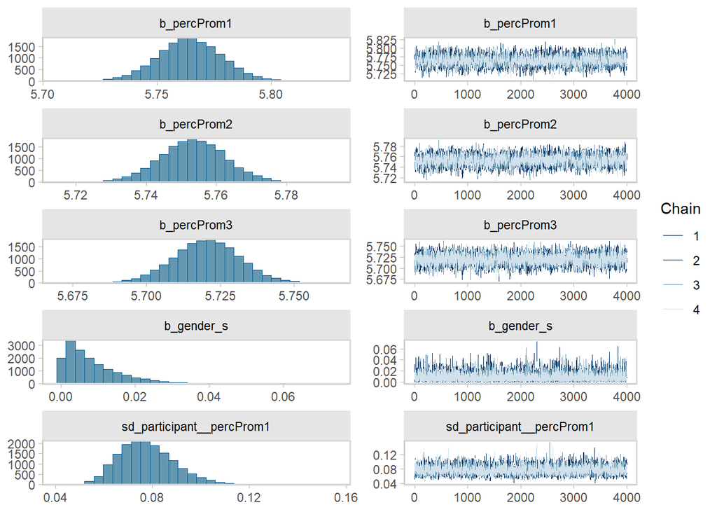

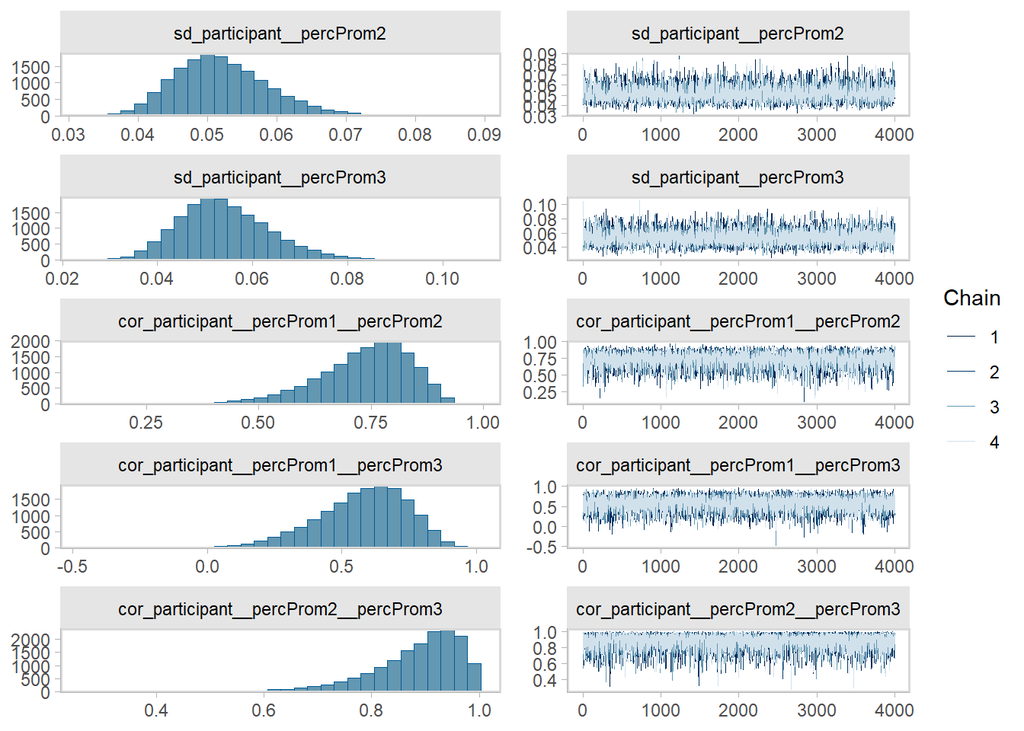

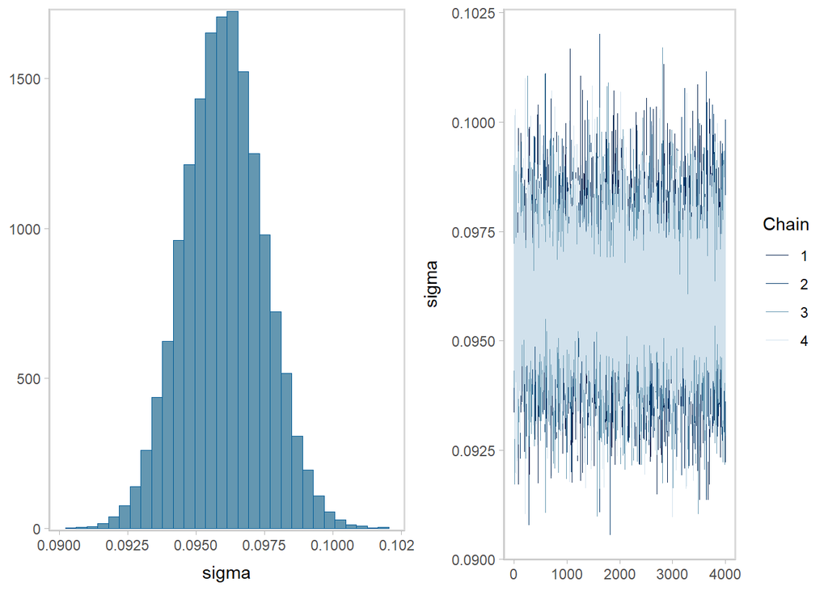

Posterior predictive check.

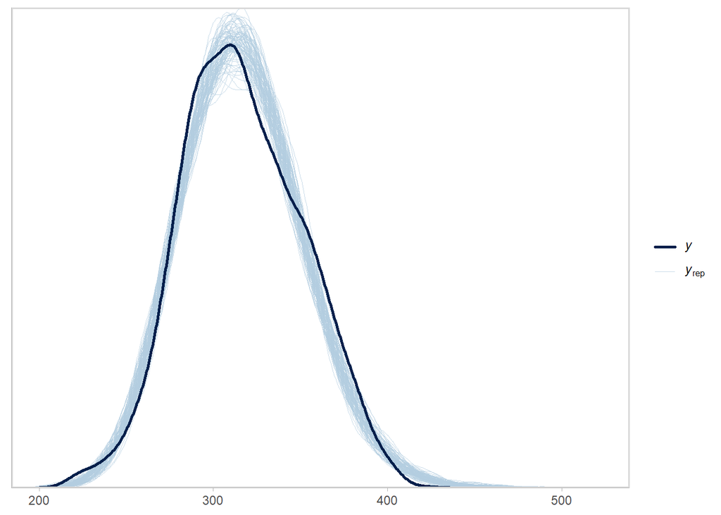